# R básico rápido

## Diagrama de barras - Colores

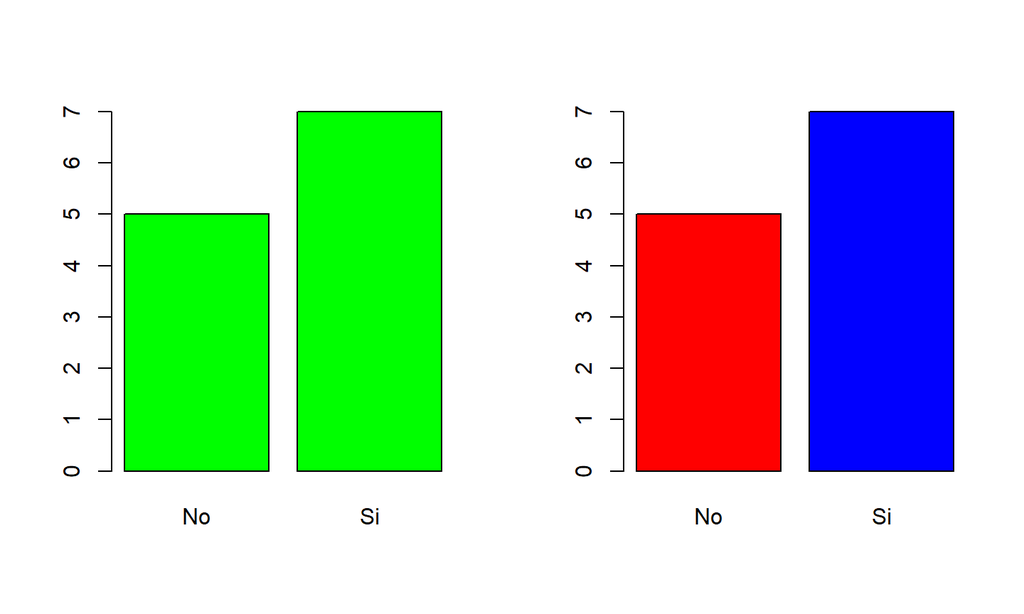

```r
par(mfrow=c(1,2))
barplot(table(Respuestas), col=c("green"))
barplot(table(Respuestas), col=c("red","blue"))
```

```r
par(mfrow=c(1,1))
```

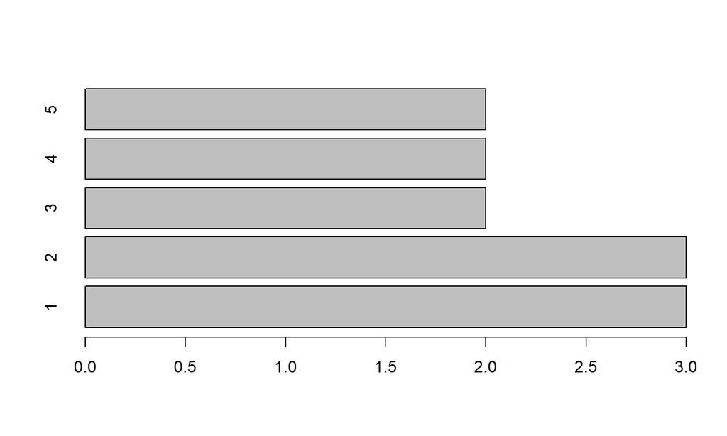

```r
barplot(table(x), horiz=TRUE)
```

## Diagrama de barras - Tabla bidimensional

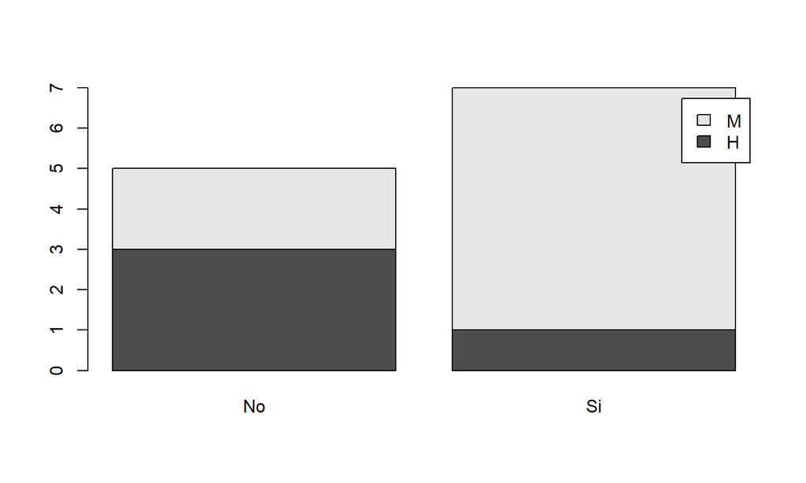

```r
barplot(table(Sexo,Respuestas), legend.text = TRUE)
```

## Diagrama de barras - Tabla bidimensional

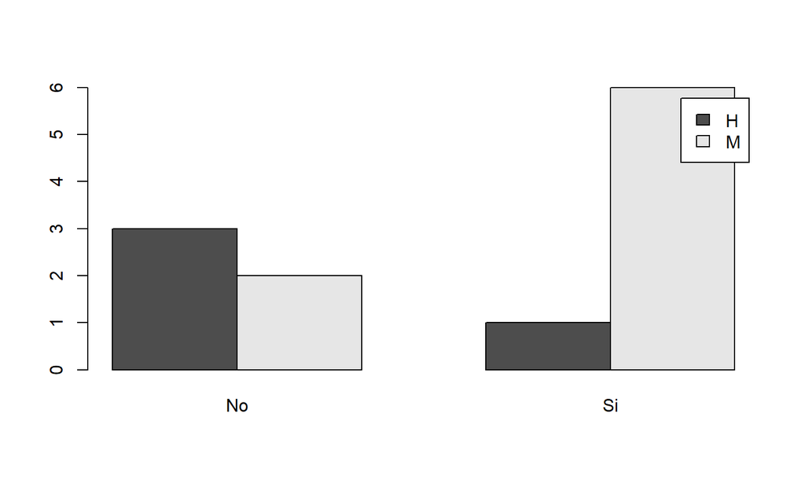

```r
barplot(table(Sexo,Respuestas), beside=TRUE,
        legend.text=TRUE)
```

## Diagrama de barras - Parámetros de las leyendas

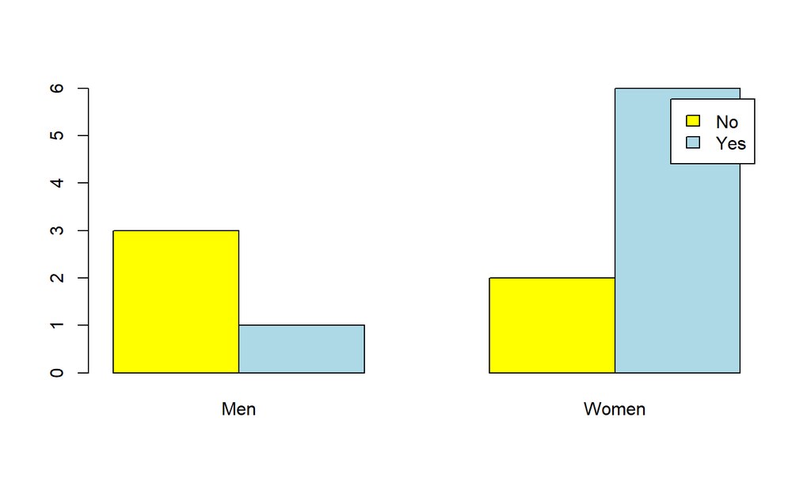

```r
barplot(table(Respuestas,Sexo), beside=TRUE,
        names=c("Men", "Women"), col=c("yellow","lightblue"),  legend.text=c("No","Yes"))
```

## Diagrama circular

Con R, este tipo de diagramas se producen con la instrucción `pie`, de nuevo aplicada a una tabla de frecuencias y no al vector original.

## Diagrama circular - Parámetros

La función `pie` admite muchos parámetros para modificar el resultado: se pueden cambiar los colores con `col`, se pueden cambiar los nombres de los niveles con `names`, se puede poner un título con `main`, etc.; podéis consultar la lista completa de parámetros en `help(pie)`.

## Diagrama circular

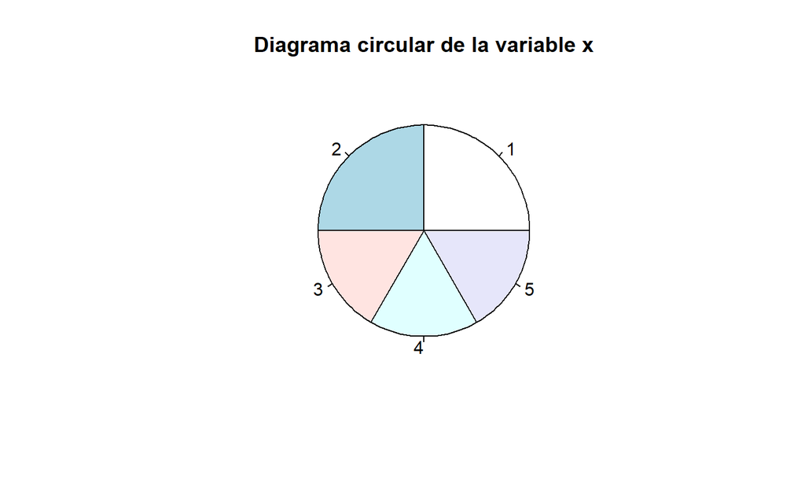

```r
pie(table(x), main="Diagrama circular de la variable x")
```

## Diagrama circular

```r
Respuestas
```

```
 [1] No No Si Si Si Si Si No No Si No Si
Levels: No Si
```

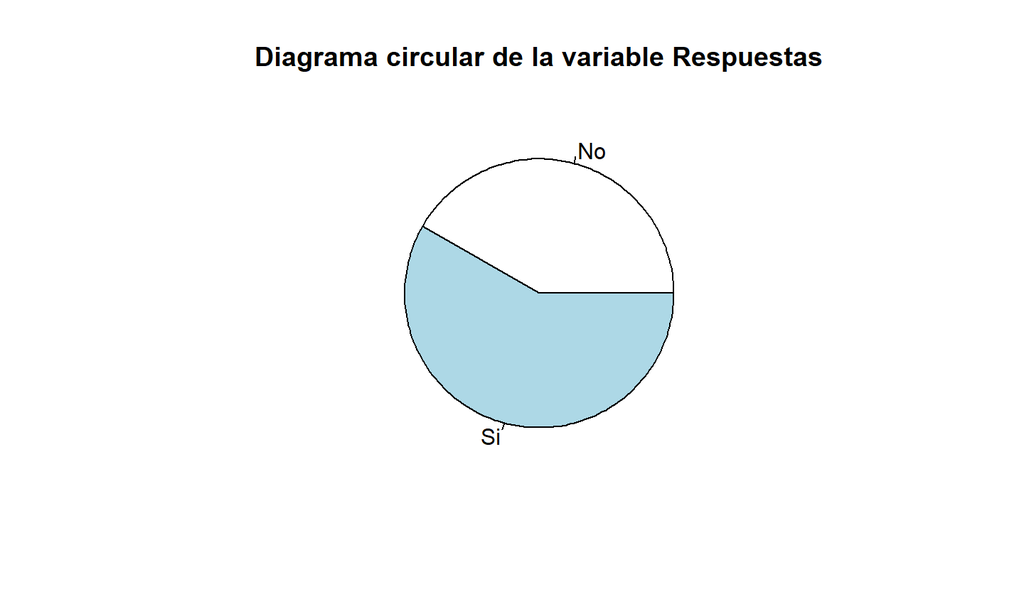

```r
pie(table(Respuestas), main="Diagrama circular de la variable Respuestas")
```

## Diagrama circular

Pese a su popularidad, es poco recomendable usar diagramas circulares porque a veces es difícil, a simple vista, comprender las relaciones entre las frecuencias que representan.

## Gráficos de mosaico

En concreto, para obtener el gráfico de mosaico de una tabla bidimensional, se parte de un cuadrado de lado 1, primero se divide en barras verticales de amplitudes iguales a las frecuencias relativas de una variable, y luego cada barra se divide, a lo alto, en regiones de alturas proporcionales a las frecuencias relativas marginales de cada nivel de la otra variable, dentro del nivel correspondiente de la primera variable.

Un gráfico de mosaico de una tabla se obtiene con R aplicando la función `plot` a la tabla, o también la función `mosaicplot`. Esta última también se puede aplicar a matrices.

## Gráficos de mosaico

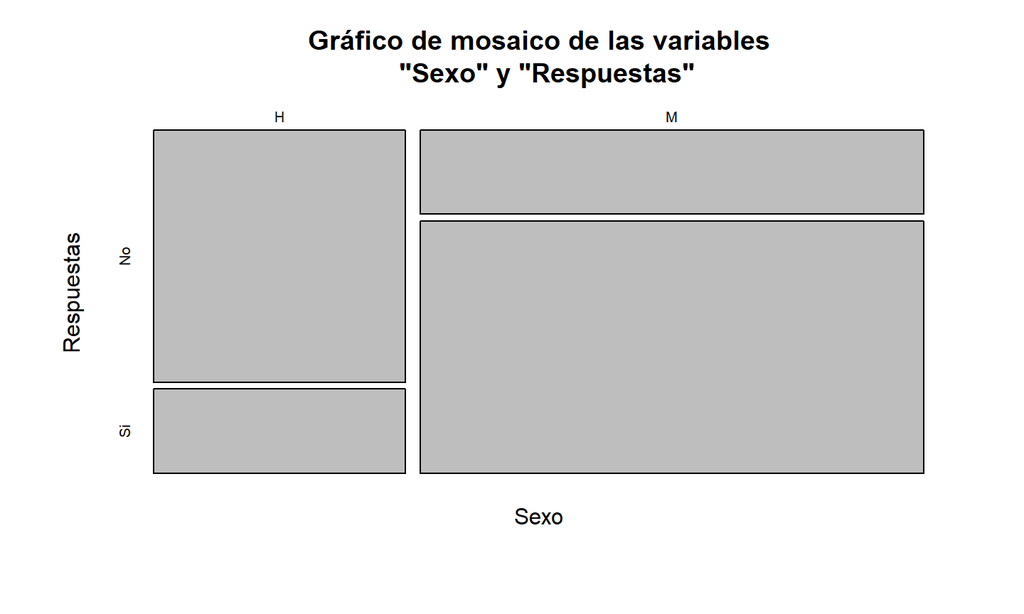

```r
plot(table(Sexo,Respuestas),
main="Gráfico de mosaico de las variables
  \"Sexo\" y \"Respuestas\"")
```

## Gráficos de mosaico

En el gráfico de mosaico de una tabla tridimensional, primero se divide el cuadrado en barras verticales de amplitudes iguales a las frecuencias relativas de una variable.

Luego cada barra se divide, a lo alto, en regiones de alturas proporcionales a las frecuencias relativas marginales de cada nivel de una segunda variable, dentro del nivel correspondiente de la primera variable.

Finalmente, cada sector rectangular se vuelve a dividir a lo ancho en regiones de amplitudes proporcionales a las frecuencias relativas marginales de cada nivel de la tercera variable dentro de la combinación correspondiente de niveles de las otras dos.

## Gráficos de mosaico

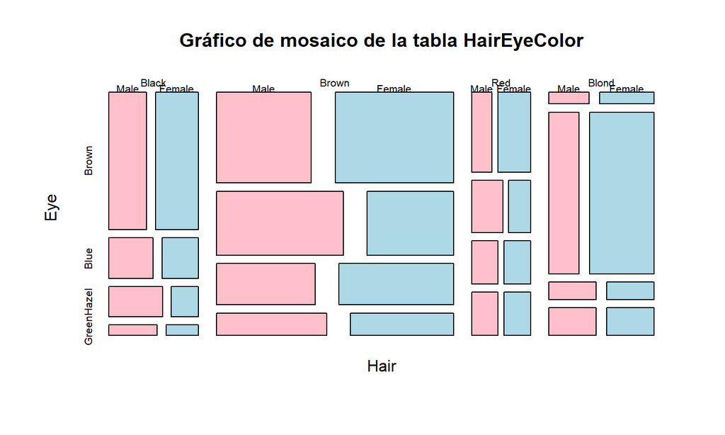

```r
plot(HairEyeColor, main="Gráfico de mosaico de la tabla HairEyeColor",
     col=c("pink","lightblue"))
```

## Muchos más gráficos

Además de sus parámetros usuales, la función `plot` admite algunos parámetros específicos cuando se usa para producir el gráfico de mosaico de una tabla. Estos parámetros se pueden consultar en `help(mosaicplot)`.

Los paquetes `vcd` y `vcdExtra` incluyen otras funciones que producen representaciones gráficas interesantes de tablas tridimensionales.

- La función `cotabplot` de `vcd` produce un diagrama de mosaico para cada nivel de la tercera variable.
- La función `mosaic3d` de `vcdExtra` produce un diagrama de mosaico tridimensional en una ventana de una aplicación para gráficos 3D interactivos.

## Lección 13: Ejemplo final

## Un ejemplo final

Vamos a llevar a cabo un análisis completo de un ejemplo con lo que hemos aprendido en esta lección y aprovecharemos para aprender algo nuevo.

El objeto de datos `HairEyeColor` que lleva predefinido R es una tabla de frecuencias absolutas de tres variables cualitativas: color de cabello (`Hair`), color de los ojos (`Eye`) y sexo (`Sex`).

Vamos a extraer de esta tabla una tabla bidimensional de frecuencias absolutas de las variables `Eye` y `Hair`, sin distinguir según el sexo. La manera más sencilla de obtener esta tabla es sumando las subtablas de frecuencias para hombres y mujeres, y aplicando `as.table()` al resultado para transformarlo en una `table` por si no lo es.

## Un ejemplo final

Vamos a traducir al castellano los nombres de las variables de esta tabla y de sus niveles. Esto lo podemos llevar a cabo en un solo paso con la función `dimnames()` que ya usamos sobre data frames. El resultado de aplicar esta función a una table es una `list` cuyas componentes son los niveles de cada variable.

```r
dimnames(HEC)
```

```
$Hair
[1] "Black" "Brown" "Red"   "Blond"

$Eye
[1] "Brown" "Blue"  "Hazel" "Green"
```

**Ejercicio.**

Redefinid dicha `list` para tener los niveles de los factores en castellano

## Un ejemplo final

Vamos a dibujar un diagrama de mosaico de esta tabla, para visualizar gráficamente sus entradas.

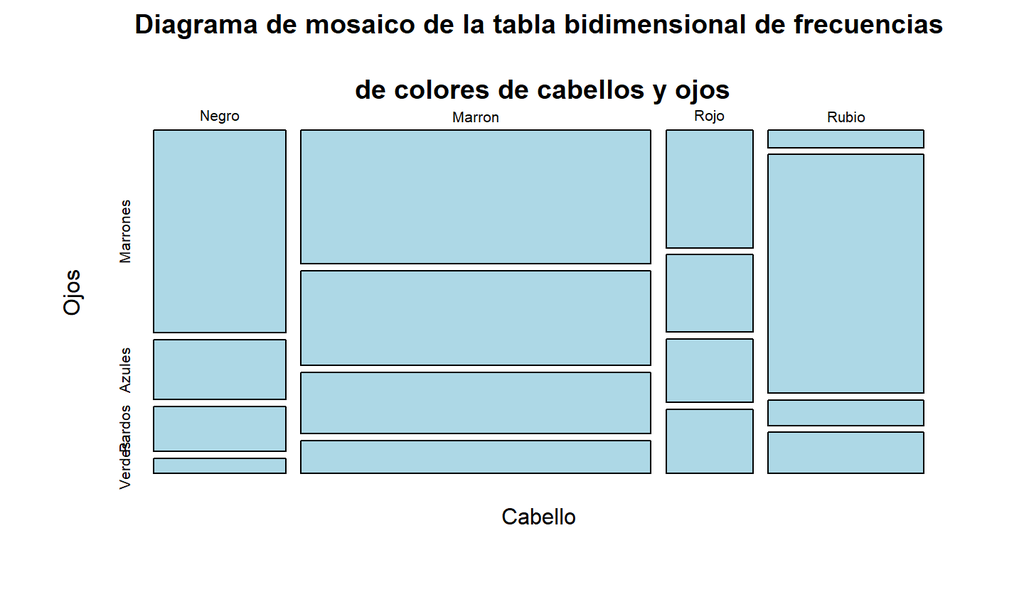

## Un ejemplo final

A continuación, vamos a calcular el número total de individuos representados en esta tabla:

```
[1] 592
```

## Un ejemplo final

Las tablas de frecuencias absolutas y relativas de cada variable,

```
Marrones   Azules   Pardos   Verdes
     220      215       93       64
```

```
 Negro Marron   Rojo  Rubio
   108    286     71    127
```

```
Marrones   Azules   Pardos   Verdes
   0.372    0.363    0.157    0.108
```

```
 Negro Marron   Rojo  Rubio
 0.182  0.483  0.120  0.215
```

## Un ejemplo final

Representaremos estas últimas en sendos diagramas de barras.

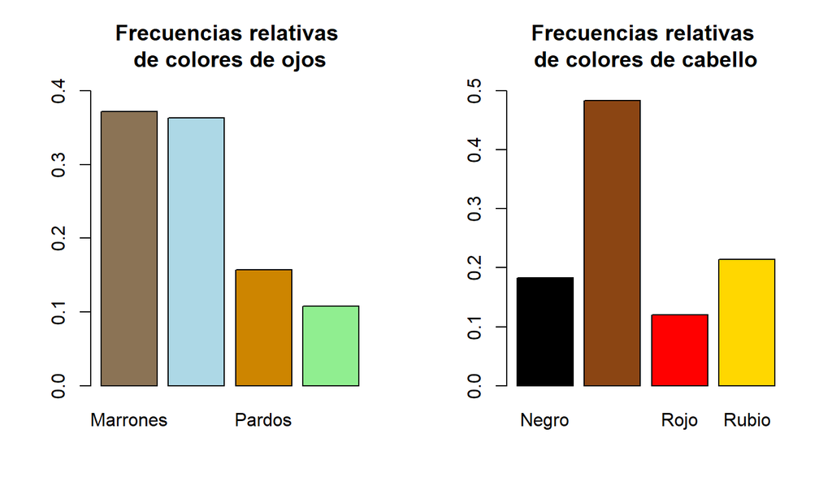

## Un ejemplo final

En el diagrama anterior vemos que el color dominante de cabellos es el castaño, mientras que en el color de ojos el marrón y el azul están prácticamente empatados. Pasamos ahora a calcular las tablas de frecuencias relativas y dibujar los dos diagramas de barras de las frecuencias relativas marginales.

```
        Ojos
Cabello  Marrones Azules Pardos Verdes
  Negro     0.115  0.034  0.025  0.008
  Marron    0.201  0.142  0.091  0.049
  Rojo      0.044  0.029  0.024  0.024
  Rubio     0.012  0.159  0.017  0.027
```

## Un ejemplo final

```
        Ojos
Cabello  Marrones Azules Pardos Verdes
  Negro     0.630  0.185  0.139  0.046
  Marron    0.416  0.294  0.189  0.101
  Rojo      0.366  0.239  0.197  0.197
  Rubio     0.055  0.740  0.079  0.126
```

```
        Ojos
Cabello  Marrones Azules Pardos Verdes
  Negro     0.309  0.093  0.161  0.078
  Marron    0.541  0.391  0.581  0.453
  Rojo      0.118  0.079  0.151  0.219
  Rubio     0.032  0.437  0.108  0.250
```

## Un ejemplo final

[figure not shown]

## Un ejercicio para vosotros

**Ejercicio**

Instalad y cargad el paquete `MASS`. Encontraréis una tabla de datos llamada `birthwt` sobre factores que pueden incidir en el peso de los niños al nacer. Con `str()` y `head()`, explorad la estructura, y con `help()`, mirad el significado de cada variable.

- Calculad una tabla de frecuencias relativas marginales de los pares (raza de la madre, peso inferior a 2.5 kg o no) que permita ver si la raza de la madre influye en el peso del bebé. Dibujad un diagrama de mosaico de esta tabla.
- Dibujad un diagrama bidimensional de barras, con las barras organizadas en bloques, que permita visualizar esta información. Poned nombres adecuados a los bloques, colores a las barras, y añadid una leyenda que explique qué representa cada barra. ¿Se puede obtener alguna conclusión de esta tabla y de este diagrama de barras?

## Un ejercicio para vosotros

- Repetid los dos puntos anteriores para los pares (madre fumadora o no, peso inferior a 2.5 kg o no) y para los pares (madre hipertensa o no, peso inferior a 2.5 kg o no).
- Calculad una tabla de frecuencias relativas marginales de las ternas (raza de la madre, madre fumadora o no, peso inferior a 2.5 kg o no) que permita ver si la raza de la madre y su condición de fumadora o no fumadora influyen en el peso del bebé. Dibujad un diagrama de mosaico de esta tabla.

## Lección 14: Analisis de datos ordinales

## Descripción de datos ordinales

La diferencia existente entre los datos cualitativos y los ordinales reside en las características que expresan. En el caso de los ordinales, éstas tienen un orden natural que permite “acumular” observaciones.

## Frecuencias para datos ordinales

Es decir, podemos contar cuantas veces hemos observado un dato menor o igual a este.

## Ejemplo 1

**Ejemplo 1**

Suponed que tenemos una muestra de 15 estudiantes de los cuales sabemos su nota en el examen de Estadística. Clasificamos todos estos resultados en Suspenso (\(S\)), Aprobado (\(A\)), Notable (\(N\)) y Excelente (\(Ex\)) y consideramos su orden natural \(S<A<N<Ex\).

Las notas obtenidas han sido las siguientes \[S,\ A,\ N,\ Ex,\ S,\ S,\ Ex,\ Ex,\ N,\ A,\ A,\ A,\ A,\ N,\ S\]

Como recordaréis, para saber cuantas hay de cada una (su frecuencia absoluta), utilizamos la función `table()`

## Ejemplo 1

```r
notas = ordered(c("S","A", "N", "Ex", "S", "S",
                  "Ex","Ex", "N", "A", "A", "A",
                  "A", "N", "S"),
                levels = c("S", "A", "N", "Ex"))
table(notas)
```

```
notas
 S  A  N Ex
 4  5  3  3
```

Como podréis observar, hay 4 \(S\), 5 \(A\), 3 \(N\) y 3 \(Ex\).

## Ejemplo 1

En lo referente a **frecuencias absolutas acumuladas**, hay

- 4 estudiantes con \(S\) o menos. Ello implica que la frecuencia acumulada de \(S\) es 4
- 9 estudiantes que han obtenido \(A\) o menos. Entonces, la frecuencia acumulada de \(A\) es 9
- 12 estudiantes los cuales han obtenido \(N\) o menos. Así, la frecuencia acumulada de \(N\) es 12
- 15 estudiantes (todos) que han obtenido \(Ex\) o menos. De este modo, la frecuencia acumulada de \(Ex\) es 15, o sea, el total.

## Ejemplo 1

Es la fracción del total de las observaciones en tanto por 1 que representa su frecuencia absoluta acumulada

Así, las recuencias relativas acumuladas respectivas son

- \(S:\ \frac{4}{15} \approx\) 0.27
- \(A:\ \frac{9}{15}\approx\) 0.6
- \(N:\ \frac{12}{15}\approx\) 0.8
- \(Ex:\ \frac{15}{15}=1\)

## Frecuencia relativa acumulada

En general, supongamos que realizamos \(n\) observaciones

\[x_1,\dots,x_n\]

de un cierto tipo de datos ordinales, cuyos posibles niveles ordenados son

\[l_1<l_2<\dots<l_k\]

## Frecuencia relativa acumulada

Además, nuestro \(n = 15\) y nuestros \(x_1,\dots,x_{15}\) son las calificaciones obtenidas por los alumnos.

De este modo, con estas notaciones

- Las definiciones de frecuencias absolutas \(n_j\) y las relativas \(f_j\), para cada nivel \(l_j\) son las mismas que en una variable cualitativa.
- Las frecuencia absoluta acumulada del nivel \(l_j\) en esta variable ordinal es el número \(N_j\) de observaciones \(x_i\) tales que \(x_i\le l_j\). Es decir, \[N_j=\sum_{i=1}^jn_i\]

## Frecuencia relativa acumulada

- La frecuencia relativa acumulada del nivel \(l_j\) en esta variable ordinal es la fracción en tanto por 1 \(F_j\) de observaciones \(x_i\) tales que \(x_i\le l_j\). Es decir, \[F_j=\frac{N_j}{n}=\sum_{i=1}^jf_i\]

## Ejemplo 2

**Ejemplo 2**

En un estudio, a un grupo de clientes de un restaurante se les hizo la siguiente pregunta:

“¿Estás contento con el trato ofrecido por los trabajadores del establecimiento?”

Las posibles respuestas forman una escala ordinal con \(1<2<3<4<5\).

Supongamos que se recogieron las siguientes respuestas de 50 técnicos:

```r
set.seed(2018)
clientes = sample(1:5, 50, replace = TRUE)
clientes
```

```
 [1] 3 4 5 2 5 1 3 4 2 4 3 3 1 1 5 3 1 3 3 5 1 4 2 5 3 4 5 1 2 2 1 5 5 2 1 2 5 5
[39] 2 1 2 1 3 2 1 2 3 3 1 2
```

```r
set.seed(NULL)
```

## Ejemplo 2

En este caso tenemos 5 niveles (\(k=5\)) y 50 observaciones (\(n=50\)) que forman una variable ordinal a la que hemos llamado `clientes`.

Hemos calculado todas sus frecuencias (absoluta, relativa, acumulada y relativa acumulada) y las hemos representado en la siguiente talbla.

```
  Absoluta Relativa Acumulada Rel. Acumulada
1       12     0.24        12           0.24
2       12     0.24        24           0.48
3       11     0.22        35           0.70
4        5     0.10        40           0.80
5       10     0.20        50           1.00
```

**Ejercicio.** Calculad todas las frecuencias y comprobad que son exactamente estas.

## Frecuencia relativa acumulada

Los gráficos para frecuencias absolutas y relativas absolutas de variables ordinales son exactamente los mismos que para las variables cualitativas.

También podemos utilizar diagramas de barras para describir frecuencias acumuladas: en este caso, la altura de cada barra debe ser igual a la frecuencia acumulada del nivel respectivo. Además, estos niveles deben de aparecer ordenados de manera ascendente, de forma que las alturas de las barras también tengan un orden ascendente.

No obstante, se recomienda no hacer uso de diagramas circulares a la hora de representar frecuencias acumuladas, debido a que éstos no representan la información sobre la acumulación de datos de forma fácil de entender a simple vista.

## Lección 15: Descripción de datos ordinales con R

## Función cumsum()

¿Recordáis la función `cumsum()`? Pues esta puede ser utilizada a la hora de calcular frecuencias acumuladas.

Retomemos el ejemplo anterior de las notas de los estudiantes y calculemos y representemos en un diagrama de barras las frecuencias acumuladas de la muestra de notas.

```r
notas
```

```
 [1] S  A  N  Ex S  S  Ex Ex N  A  A  A  A  N  S
Levels: S < A < N < Ex
```

```r
fAbs = table(notas) #Frec. abs.
cumsum(fAbs) #Frec. abs. acumuladas
```

```
 S  A  N Ex
 4  9 12 15
```

## Función cumsum()

```r
cumsum(prop.table(fAbs)) #Frec. relativas acumuladas
```

```
        S         A         N        Ex
0.2666667 0.6000000 0.8000000 1.0000000
```

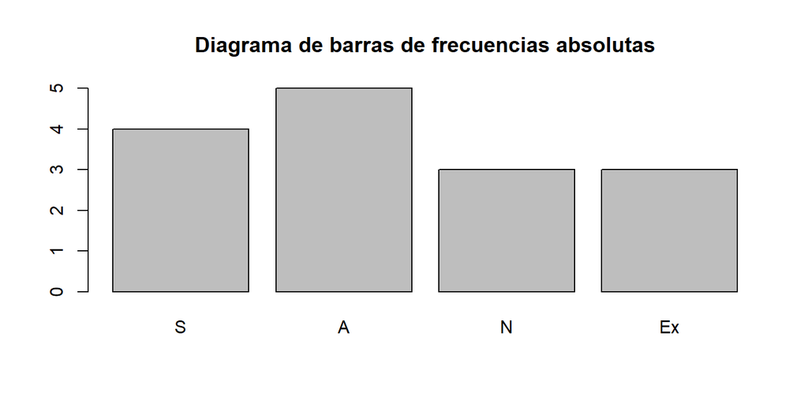

```r
barplot(fAbs, main = "Diagrama de barras de frecuencias absolutas")
```

## Función cumsum()

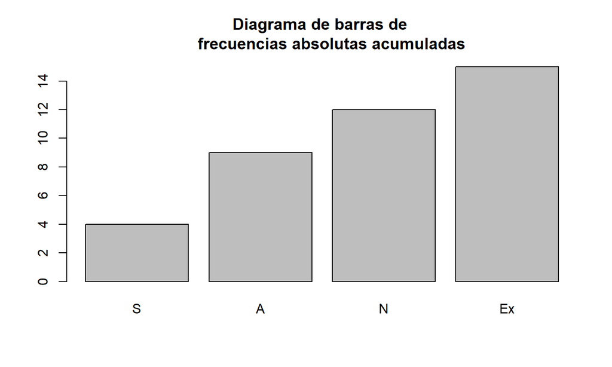

```r
barplot(cumsum(fAbs), main = "Diagrama de barras de
    frecuencias absolutas acumuladas")
```

## Función cumsum()

Podríamos haber calculado las frecuencias relativas acumuladas de la forma

```r
cumsum(table(notas))/length(notas)
```

```
        S         A         N        Ex
0.2666667 0.6000000 0.8000000 1.0000000
```

```r
cumsum(table(notas)/length(notas))
```

```
        S         A         N        Ex
0.2666667 0.6000000 0.8000000 1.0000000
```

## Función cumsum()

Pero no podemos hacer `prop.table(cumsum(table(notas)))`.

**Ejercicio.** Pensad qué ha entendido R que queríamos hacer con esta última instrucción.

## Ejemplo 3

**Ejemplo 3**

Se ha evaluado el tamaño de los cuellos de 100 jirafas. Los niveles que se han utilizado se los considera ordenados de la siguiente manera:

\[\text{Muy.corto}<\text{Corto}<\text{Normal}<\text{Largo}<\text{Muy.largo}\]

Los valores obtenidos en dicho estudio han sido los siguientes

## Ejemplo 3

```r
longitud
```

```
  [1] Normal    Largo     Muy.largo Corto     Muy.largo Muy.corto Normal
  [8] Largo     Corto     Largo     Normal    Normal    Muy.corto Muy.corto
 [15] Muy.largo Normal    Muy.corto Normal    Normal    Muy.largo Muy.corto
 [22] Largo     Corto     Muy.largo Normal    Largo     Muy.largo Muy.corto
 [29] Corto     Corto     Muy.corto Muy.largo Muy.largo Corto     Muy.corto
 [36] Corto     Muy.largo Muy.largo Corto     Muy.corto Corto     Muy.corto
 [43] Normal    Corto     Muy.corto Corto     Normal    Normal    Muy.corto
 [50] Corto     Normal    Muy.corto Largo     Largo     Corto     Muy.corto
 [57] Corto     Normal    Normal    Normal    Normal    Muy.corto Normal
 [64] Muy.corto Corto     Largo     Muy.corto Corto     Muy.corto Muy.largo
 [71] Muy.corto Corto     Muy.largo Largo     Muy.largo Normal    Corto
 [78] Corto     Normal    Largo     Largo     Corto     Corto     Muy.largo
 [85] Largo     Largo     Normal    Normal    Muy.corto Normal    Corto
 [92] Normal    Muy.corto Corto     Muy.corto Normal    Corto     Corto
 [99] Muy.corto Corto
Levels: Muy.corto < Corto < Normal < Largo < Muy.largo
```

## Ejemplo 3

Estudiemos sus frecuencias

```r
Fr.Abs = table(longitud)
Fr.Abs
```

```
longitud
Muy.corto     Corto    Normal     Largo Muy.largo
       23        26        24        13        14
```

```r
Fr.Rel = prop.table(Fr.Abs)
Fr.Rel
```

```
longitud
Muy.corto     Corto    Normal     Largo Muy.largo
     0.23      0.26      0.24      0.13      0.14
```

## Ejemplo 3

```r
Fr.Acum = cumsum(Fr.Abs)
Fr.Acum
```

```
Muy.corto     Corto    Normal     Largo Muy.largo
       23        49        73        86       100
```

```r
Fr.RAcum = cumsum(Fr.Rel)
Fr.RAcum
```

```
Muy.corto     Corto    Normal     Largo Muy.largo
     0.23      0.49      0.73      0.86      1.00
```

## Ejemplo 3

La instrucción `barplot` produce el siguiente diagrama de barras de frecuencias relativas acumuladas

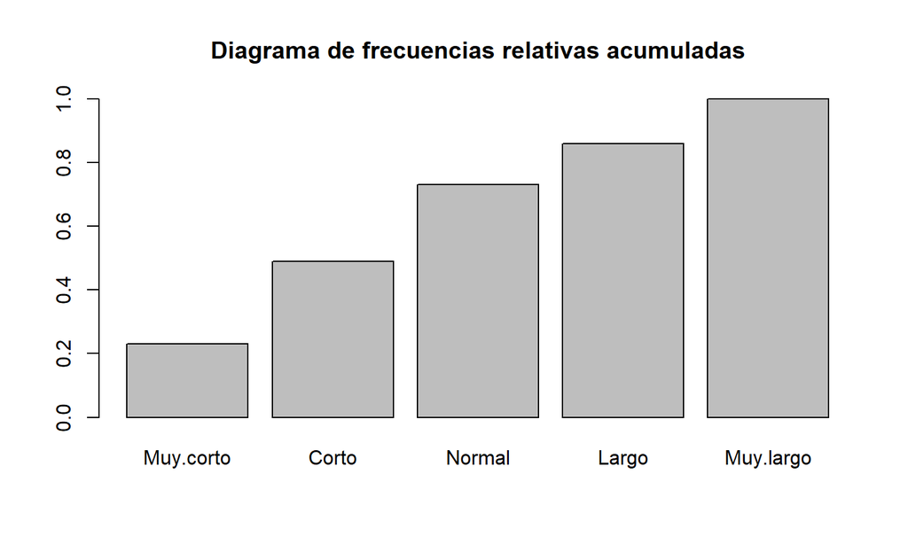

```r
barplot(Fr.RAcum, main = "Diagrama de frecuencias relativas acumuladas")
```

## Función cumsum()

Para calcular frecuencias acumuladas en una tabla multidimensional, hay que aplicar a la tabla la función `cumsum` mediante la función `apply` que ya explicábamos para matrices. En este caso en concreto, la sintaxis de la instrucción sería

`apply(tabla, MARGIN=..., FUN=cumsum)`

donde el valor `MARGIN` ha de ser el de la dimensión en la que queremos acumular las frecuencias: 1 si queremos hacerlo por filas, 2 para hacerlo por columnas, etc. Lo veremos todo más claro con un ejemplo

## Ejemplo 4

**Ejemplo 4**

Supongamos que en el ejemplo anterior, el de las jirafas, estas provienen de 4 zonas diferentes, A,B,C y D, de manera que las 30 primeras son de la zona A, las 25 siguientes de la B, las 35 siguientes de la C y las 10 últimas de la D. Nos interesa estudiar la distribución de las longitudes según la zona.

Vamos a organizar todos estos datos en un data frame llamado `jirafas`. Para que nos sea más fácil visualizar la información, es conveniente que las filas de las tablas de frecuencias correspondan a las zonas. Por lo tanto, al definir el data frame, entraremos como primera variable la de la muestra las zonas. Así, conseguiremos que éstas aparezcan en las filas al aplicarle la función table.

## Ejemplo 4

```r
zonas = rep(c("A","B","C","D"), c(30,25,35,10))
jirafas = data.frame(zonas,longitud)
str(jirafas)
```

```
'data.frame':   100 obs. of  2 variables:
 $ zonas   : chr  "A" "A" "A" "A" ...
 $ longitud: Ord.factor w/ 5 levels "Muy.corto"<"Corto"<..: 3 4 5 2 5 1 3 4 2 4 ...
```

```r
head(jirafas)
```

```
  zonas  longitud
1     A    Normal
2     A     Largo
3     A Muy.largo
4     A     Corto
5     A Muy.largo
6     A Muy.corto
```

## Ejemplo 4

Para calcular la tabla de frecuencias absolutas acumuladas de las longitudes por zonas y como las zonas definen las filas de la tabla anterior, debemos utilizar la función `apply` con `MARGIN = 1`.

```r
apply(table(jirafas), MARGIN = 1, FUN = cumsum)
```

```
           zonas
longitud     A  B  C  D
  Muy.corto  6  7  7  3
  Corto     11 15 15  8
  Normal    19 19 25 10
  Largo     24 21 31 10
  Muy.largo 30 25 35 10
```

## Ejemplo 4

Fijaos que la tabla se ha traspuesto. Resulta que cuando se aplica `apply` a una `table` bidimensional, R intercambia, en caso de ser necesario, filas por columnas en el resultado para que la dimensión de la tabla resultante en la que se haya aplicado la función sea la de las columnas.

Con lo cual, para volver a tener las zonas en las filas, hay que trasponer el resultado de la función `apply`.

```r
t(apply(table(jirafas), MARGIN = 1, FUN = cumsum))
```

```
     longitud
zonas Muy.corto Corto Normal Largo Muy.largo
    A         6    11     19    24        30
    B         7    15     19    21        25
    C         7    15     25    31        35
    D         3     8     10    10        10
```

## Ejemplo 4

Vamos ahora a calcular la tabla de frecuencias relativas acumuladas de las longitudes de cuello por zonas. Para conseguirlo, y en una única instrucción, primero calculamos la tabla de frecuencias relativas por filas, a continuación, con las funciones `apply` y `cumsum` las acumulamos y, finalmente, trasponemos el resultado.

```r
t(apply(prop.table(table(jirafas),
                   margin = 1),
        MARGIN = 1, FUN = cumsum))
```

```
     longitud
zonas Muy.corto     Corto    Normal     Largo Muy.largo
    A      0.20 0.3666667 0.6333333 0.8000000         1
    B      0.28 0.6000000 0.7600000 0.8400000         1
    C      0.20 0.4285714 0.7142857 0.8857143         1
    D      0.30 0.8000000 1.0000000 1.0000000         1
```

## Ejemplo 4

Vamos ahora a dibujar el diagrama de barras por bloques de esta tabla. Nos interesa que las barras de este diagrama se agrupen por zonas. Entonces, tendremos que aplicar `barplot` a la tabla sin trasponer.

Además, vamos a colocar la leyenda en la esquina superior izquierda para que no se superponga a ninguna barra. También reduciremos el tamaño del texto de la leyenda para que quepa completamente.

## Ejemplo 4

```r
Diagrama = apply(prop.table(table(jirafas), margin = 1),
                 MARGIN = 1, FUN = cumsum)
barplot(Diagrama, beside = TRUE, legend = TRUE,
main = "Diagrama de barras de frecuencias relativas acumuladas
        de longitudes por zonas",
args.legend=list(x="topleft", cex=0.55))
```

## Ejemplo 4

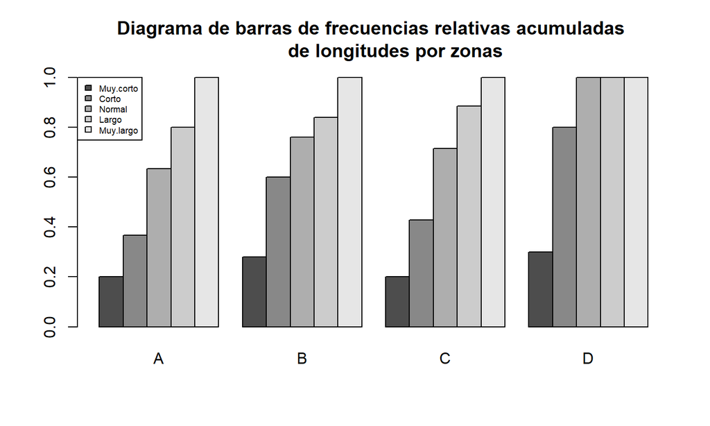

## Ejemplo 5

**Ejemplo 5**

Consideremos el data frame `datacrab` y arreglemos los datos.

```r
crabs = read.table("../data/datacrab.txt", header = TRUE)
crabs = crabs[,-1] #Omitimos la primera columna
str(crabs)
```

```
'data.frame':   173 obs. of  5 variables:
 $ color : int  3 4 2 4 4 3 2 4 3 4 ...
 $ spine : int  3 3 1 3 3 3 1 2 1 3 ...
 $ width : num  28.3 22.5 26 24.8 26 23.8 26.5 24.7 23.7 25.6 ...
 $ satell: int  8 0 9 0 4 0 0 0 0 0 ...
 $ weight: int  3050 1550 2300 2100 2600 2100 2350 1900 1950 2150 ...
```

La variable numérica `width` contiene la anchura de cada cangrejo

## Ejemplo 5

```r
table(crabs$width)
```

```
  21   22 22.5 22.9   23 23.1 23.2 23.4 23.5 23.7 23.8 23.9   24 24.1 24.2 24.3
   1    1    3    3    2    3    1    1    1    3    3    1    2    1    2    2
24.5 24.7 24.8 24.9   25 25.1 25.2 25.3 25.4 25.5 25.6 25.7 25.8 25.9   26 26.1
   7    5    1    3    6    2    2    1    3    3    2    6    7    1    6    2
26.2 26.3 26.5 26.7 26.8   27 27.1 27.2 27.3 27.4 27.5 27.6 27.7 27.8 27.9   28
   8    1    6    3    3    5    2    2    1    3    6    1    2    2    2    3
28.2 28.3 28.4 28.5 28.7 28.9   29 29.3 29.5 29.7 29.8   30 30.2 30.3 30.5 31.7
   4    3    2    4    2    1    6    2    1    1    1    3    1    1    1    1
31.9 33.5
   1    1
```

## Ejemplo 5

Vamos a convertir a la variable `width` en una variable ordinal que agrupe las entradas de la variable original en niveles.

La manera más sencilla de llevarlo a cabo es utilizando la función `cut`, que estudiaremos en detalle en lecciones posteriores. Por ahora, basta con saber que la instrucción dividirá el vector numérico `crabs$width` en intervalos de extremos los puntos especificados en el argumento `breaks`. El parámetro `right = FALSE` sirve para indicar que los puntos de corte pertenecen la intervalo de su derecha, e `Inf` indica \(\infty\).

Por lo tanto, nosotros llevaremos a cabo la siguiente instrucción

```r
intervalos = cut(crabs$width, breaks = c(21,25,29,33,Inf), right = FALSE,
                 labels = c("21-25", "25-29", "29-33", "33-..."))
```

## Ejemplo 5

El resultado de la instrucción es un factor que tiene como niveles estos intervalos, identificados con las etiquetas especificadas en el parámetro `labels`. Como nostros vamos a usar estos intervalos como niveles de una variable ordinal, además convertiremos este factor en ordenado.

```r
crabs$width.rank = ordered(intervalos)
str(crabs)
```

```
'data.frame':   173 obs. of  6 variables:
 $ color     : int  3 4 2 4 4 3 2 4 3 4 ...
 $ spine     : int  3 3 1 3 3 3 1 2 1 3 ...
 $ width     : num  28.3 22.5 26 24.8 26 23.8 26.5 24.7 23.7 25.6 ...
 $ satell    : int  8 0 9 0 4 0 0 0 0 0 ...
 $ weight    : int  3050 1550 2300 2100 2600 2100 2350 1900 1950 2150 ...
 $ width.rank: Ord.factor w/ 4 levels "21-25"<"25-29"<..: 2 1 2 1 2 1 2 1 1 2 ...
```

## Ejemplo 5

Nos interesa estudiar la distribución de las anchuras de los cangrejos según el número de colores. Por lo tanto, vamos a calcular las tablas bidimensionales de frecuencais relativas y relativas acumuladas de los intervalos de las anchuras en cada nivel de `color` y las representaremos por medio de diagramas de barras.

La tabla de frecuencias absolutas de los pares se puede obtener aplicando `table` al data frame formado por la primera y última columnas.

```r
Tabla = table(crabs[,c(1,6)])
Tabla
```

```
     width.rank
color 21-25 25-29 29-33 33-...
    2     1     9     2      0
    3    19    62    13      1
    4    17    24     3      0
    5     9    12     1      0
```

## Ejemplo 5

```r
Fr.rel = round(prop.table(Tabla,margin = 1),3)
Fr.rel
```

```
     width.rank
color 21-25 25-29 29-33 33-...
    2 0.083 0.750 0.167  0.000
    3 0.200 0.653 0.137  0.011
    4 0.386 0.545 0.068  0.000
    5 0.409 0.545 0.045  0.000
```

## Ejemplo 5

```r
Fr.rel.acu = round(apply(prop.table(Tabla, margin = 1),
                         MARGIN = 1, FUN = cumsum), 3)
t(Fr.rel.acu)
```

```
     width.rank
color 21-25 25-29 29-33 33-...
    2 0.083 0.833 1.000      1
    3 0.200 0.853 0.989      1
    4 0.386 0.932 1.000      1
    5 0.409 0.955 1.000      1
```

## Ejemplo 5

```r
azul = c("cyan", "cyan4", "cyan1", "cyan3")

barplot(t(Fr.rel), beside = TRUE, legend = TRUE, ylim = c(0,1), col = azul,
        main = "Diagrama de barras de frecuencias relativas",
        args.legend=list(x = "topright", cex=0.55))
```

## Ejemplo 5

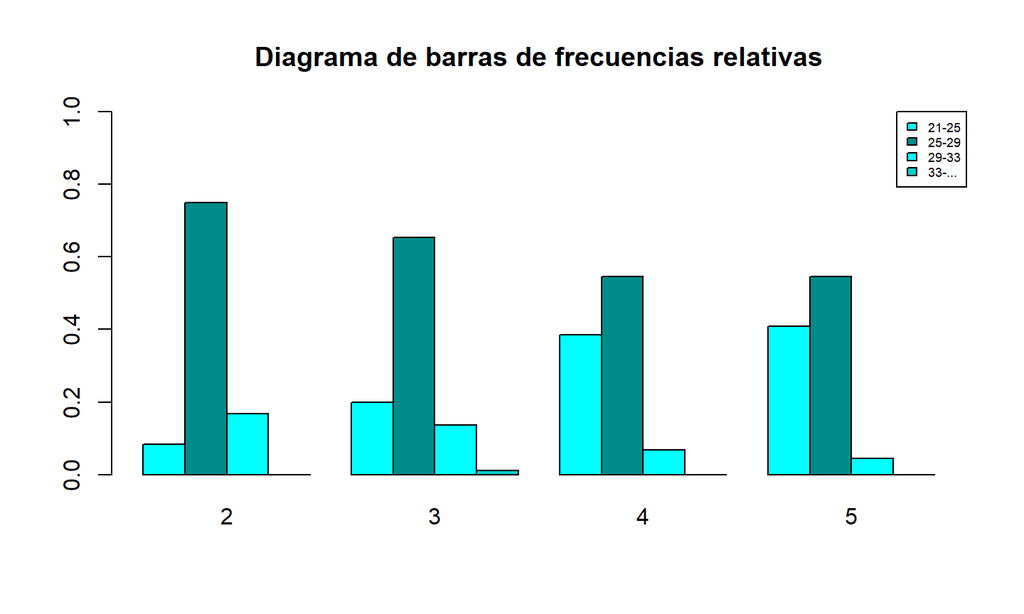

## Ejemplo 5

```r
barplot(Fr.rel.acu, beside = TRUE, legend = TRUE, col = azul,
        main = "Diagrama de barras de frecuencias relativas acumuladas",
        args.legend=list(x = "topleft", cex=0.55))
```

## Ejemplo 5

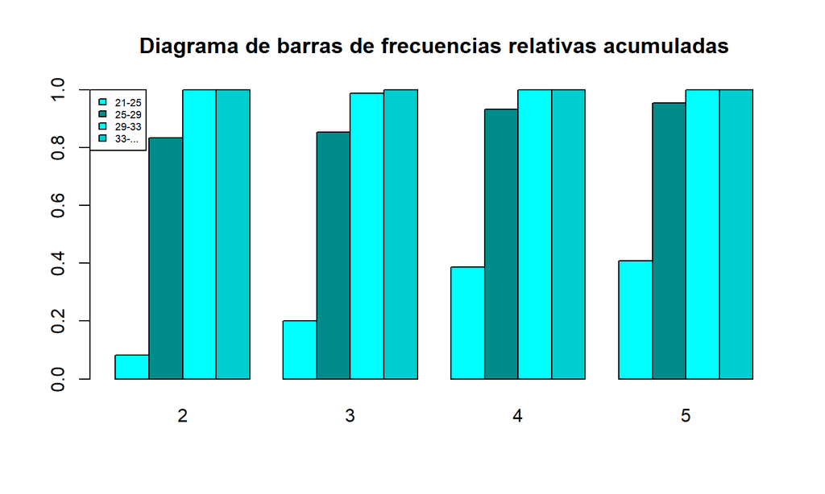

## Lección 16: Descripción de datos cuantitativos

## Datos cuantitativos

Conviene tener en cuenta que esta división es solo teórica. Es decir, en la práctica, todos estos datos son discretos puesto que la precisión infinita no existe. Sin embargo, es necesario de vez en cuando suponer los datos de tipo continuo para así poder utilizar técnicas específicas en su análisis.

## Datos cuantitativos

En este caso, disponemos de muchas otras técnicas descriptivas aparte de las frecuencias, puesto que estamos trabajando con números reales y podemos operar con ellos.

En esta lección trabajaremos sobre la primera situación. En la siguiente, estudiaremos la descripción de datos cuantitativos agrupados.

## Frecuencias de datos cuantitativos

El tratamiento de las frecuencias de datos cuantitativos es similar al de los datos ordinales. La cosa cambia ligeramente debido a que no se tienen en cuenta todos los niveles posibles, sino únicamente los observados.

## Ejemplo 1

**Ejemplo 1**

Se han pedido las edades a 20 clientes de un museo. Las respuestas obtenidas han sido las siguientes:

```r
edad = c(15,18,25,40,30,29,56,40,13,27,42,23,11,26,25,32,30,40,33,29)
```

Recordemos que solamente nos interesan las frecuencias de las edades observadas. Es decir, solamente nos interesan

```r
table(edad)
```

```
edad
11 13 15 18 23 25 26 27 29 30 32 33 40 42 56
 1  1  1  1  1  2  1  1  2  2  1  1  3  1  1
```

## Ejemplo 1

Calculemos el resto de frecuencias como ya sabemos

```r
round(prop.table(table(edad)),3)
```

```
edad
  11   13   15   18   23   25   26   27   29   30   32   33   40   42   56
0.05 0.05 0.05 0.05 0.05 0.10 0.05 0.05 0.10 0.10 0.05 0.05 0.15 0.05 0.05
```

```r
cumsum(table(edad))
```

```
11 13 15 18 23 25 26 27 29 30 32 33 40 42 56
 1  2  3  4  5  7  8  9 11 13 14 15 18 19 20
```

## Ejemplo 1

```r
round(cumsum(prop.table(table(edad))),3)
```

```
  11   13   15   18   23   25   26   27   29   30   32   33   40   42   56
0.05 0.10 0.15 0.20 0.25 0.35 0.40 0.45 0.55 0.65 0.70 0.75 0.90 0.95 1.00
```

## Frecuencias de datos cuantitativos

En general, supongamos que tenemos \(n\) observaciones de una propiedad que se mide con un número real y obtenemos la variable cuantitativa formada por los datos \[x_1,\dots, x_n\]

Sean ahora \(X_1,\dots,X_k\) los valores distintos que aparecen en esta lista de datos y considerémoslos ordenados \[X_1<X_2<\cdots<X_k\]

## Frecuencias de datos cuantitativos

Entonces, en esta variable cuantitativa

- La frecuencia absoluta de \(X_i\) es el número \(n_i\) de elementos que son iguales a \(X_i\)
- La frecuencia relativa de \(X_i\) es \(f_i=\frac{n_i}{n}\)
- La frecuencia absoluta acumulada de \(X_i\) es \(N_i=\sum_{j=1}^in_j\)
- La frecuencia relativa acumulada de \(X_i\) es \(F_i=\frac{N_i}{n}\)

## Ejemplo 2

**Ejemplo 2**

Lanzamos 25 veces un dado de 6 caras y anotamos las puntuaciones obtenidas en cada tirada.

En este caso, \(n=25\) y, los distintos valores observados son

\[X_1 = 1,\ X_2 = 2,\ X_3 = 3,\ X_4 = 4,\ X_5 = 5,\ X_6 = 6\]

Nos interesa ahora calcular las frecuencias de este experimento. Además, las organizaremos en un data frame para observarlas de forma más clara y sencilla en una tabla.

```r
set.seed(162017)
dados = sample(1:6,25,replace = TRUE)
dados
```

```
 [1] 1 1 5 5 5 5 1 6 5 4 1 3 1 3 2 2 1 1 1 4 2 1 6 3 1
```

```r
set.seed(NULL)
```

## Ejemplo 2

```r
table(dados)
```

```
dados
 1  2  3  4  5  6
10  3  3  2  5  2
```

```r
round(prop.table(table(dados)),2)
```

```
dados
   1    2    3    4    5    6
0.40 0.12 0.12 0.08 0.20 0.08
```

```r
cumsum(table(dados))
```

```
 1  2  3  4  5  6
10 13 16 18 23 25
```

## Ejemplo 2

```r
round(cumsum(prop.table(table(dados))),2)
```

```
   1    2    3    4    5    6
0.40 0.52 0.64 0.72 0.92 1.00
```

```r
dados.df = data.frame(
  Puntuacion = 1:6,
  Fr.abs = as.vector(table(dados)),
  Fr.rel = as.vector(round(prop.table(table(dados)),2)),
  Fr.acu = as.vector(cumsum(table(dados))),
  Fr.racu = as.vector(round(cumsum(
    prop.table(table(dados))),2)))
```

## Ejemplo 2

```r
dados.df
```

```
  Puntuacion Fr.abs Fr.rel Fr.acu Fr.racu
1          1     10   0.40     10    0.40
2          2      3   0.12     13    0.52
3          3      3   0.12     16    0.64
4          4      2   0.08     18    0.72
5          5      5   0.20     23    0.92
6          6      2   0.08     25    1.00
```

¡OJO! Para entrar una tabla unidimensional como una variable en un data frame, es conveniente transformarla en vector con `as.vector`. Si no, cada `table` y cada `prop.table` añadirían una columna extra con los nombres de los niveles.

## Lección 17: Medidas de tendencia central

## Medidas de tendencia central

Las medidas de tendencia central} son las que dan un valor representativo a todas las observaciones. Algunas de las más importantes son:

- La media aritmética} o valor medio} \[\bar{x} = \frac{\sum_{i=1}^nx_i}{n}=\frac{\sum_{j=1}^kn_jX_j}{n}=\sum_{j=1}^kf_jX_j\]
- La mediana}, que representa el valor central en la lista ordenada de observaciones.
- La moda} es el valor (o valores) de máxima frecuencia (absoluta o relativa, el resultado será el mismo).

## La mediana

La definición formal de la mediana es la siguiente. Denotando por \[x_{(1)}\le x_{(2)}\le\dots\le x_{(n)}\] los datos de la variable cuantitativa ordenados de menor a mayor, la mediana es

- Si \(n\) par, la medio de los dos datos centrales \[\frac{x_{(\frac{n}{2})}+x_{(\frac{n}{2}+1)}}{2}\]
- Si \(n\) impar, el dato central \(x_{(\frac{n+1}{2})}\)

## Ejemplo 1

Recordemos el ejemplo de las edades.

```r
sort(edad) #Ordenamos los datos por su orden natural
```

```
 [1] 11 13 15 18 23 25 25 26 27 29 29 30 30 32 33 40 40 40 42 56
```

```r
table(edad)
```

```
edad
11 13 15 18 23 25 26 27 29 30 32 33 40 42 56
 1  1  1  1  1  2  1  1  2  2  1  1  3  1  1
```

## Ejemplo 2

Recordemos el ejemplo de los dados.

```r
dados.df
```

```
  Puntuacion Fr.abs Fr.rel Fr.acu Fr.racu
1          1     10   0.40     10    0.40
2          2      3   0.12     13    0.52
3          3      3   0.12     16    0.64
4          4      2   0.08     18    0.72
5          5      5   0.20     23    0.92
6          6      2   0.08     25    1.00
```

## Medidas de tendencia central en R

Vamos a calcular la media aritmética, mediana y moda de los dos ejemplos anteriores con instrucciones de R.

```r
mean(edad) #La media aritmética
```

```
[1] 29.2
```

```r
mean(dados)
```

```
[1] 2.8
```

```r
median(edad) #La mediana
```

```
[1] 29
```

## Medidas de tendencia central en R

```r
median(dados)
```

```
[1] 2
```

```r
as.numeric(names(which(
  table(edad)==max(table(edad))))) #La moda
```

```
[1] 40
```

```r
as.numeric(names(which(
  table(dados)==max(table(dados)))))
```

```
[1] 1
```

Cuando trabajamos con datos cuantitativos, es conveniente que el resultado lo demos como un número. De ahí que hayamos aplicado la función `as.numeric`.

## Lección 18: Medidas de posición

## Medidas de posición

Pensándolo de este modo, la mediana puede interpretarse como una medida de posición, debido a que divide la variable cuantitativa en dos mitades.

## Medidas de posición

Dicho de otro modo, si tenemos un conjunto de observaciones \(x_1,\dots,x_n\) y los ordenamos de menor a mayor, entonces \(Q_p\) será el número más pequeño que deja a su izquierda (incluyéndose a sí mismo) como mínimo a la fracción \(p\) de los datos. Es decir, \(p\cdot n\).

Así, ahora es más claro ver que la mediana vendría a ser \(Q_{0.5}\), el cuantil de orden 0.5.

## Ejemplo 3

**Ejemplo 3**

Consideremos un experimento en el que lanzamos 50 veces un dado de 4 caras y obtenemos los siguientes resultados

```r
set.seed(260798)
dado = sample(1:4, 50, replace = TRUE)
set.seed(NULL)
length(dado)
```

```
[1] 50
```

```r
dado = sort(dado) #Los ordenamos de menor a mayor
dado
```

```
 [1] 1 1 1 1 1 1 1 1 1 1 1 1 1 1 1 1 2 2 2 2 2 2 2 2 2 2 2 2 2 2 2 3 3 3 3 3 4 4
[39] 4 4 4 4 4 4 4 4 4 4 4 4
```

## Ejemplo 3

```r
df.dado = data.frame(
  Puntuacion = 1:4,
  Fr.abs = as.vector(table(dado)),
  Fr.rel = as.vector(round(prop.table(table(dado)),2)),
  Fr.acu = as.vector(cumsum(table(dado))),
  Fr.racu = as.vector(round(cumsum(
    prop.table(table(dado))),2))
  )
df.dado
```

```
  Puntuacion Fr.abs Fr.rel Fr.acu Fr.racu
1          1     16   0.32     16    0.32
2          2     15   0.30     31    0.62
3          3      5   0.10     36    0.72
4          4     14   0.28     50    1.00
```

## Ejemplo 3

Si nos piden el cuantil \(Q_{0.3}\), sabemos que este es el primer elemento de la lista cuya frecuencia relativa acumulada es mayor o igual a 0.3. Este se corresponde con la puntuación 1.

## Ejemplo 3

También podríamos hallarlo de otro modo: fijándonos en la lista ordenada de puntuaciones, el cuantil \(Q_{0.3}\) sería el primer elemento de dicha lista tal que fuera mayor o igual que, como mínimo, el 30% de los datos. Si calculamos el 30% de 50, obtenemos que es 15. Esto lo que nos dice es que el cuantil que buscamos es el número que se encuentrae en la quinceava posición de la lista ordenada.

```r
dado[15]
```

```
[1] 1
```

## Cuantiles

Algunos cuantiles tienen nombre propio:

- Los cuartiles} son los cuantiles \(Q_{0.25},Q_{0.5}\) y \(Q_{0.75}\). Respectivamente, son llamados primer, segundo y tercer cuartil. El primer cuartil, \(Q_{0.25}\), será el menor valor que es mayor o igual a una cuarta parte de las observaciones y \(Q_{0.75}\), el menor valor que es mayor o igual a tres cuartas partes de los datos observados.
- El cuantil \(Q_{0.5}\) es la mediana
- Los deciles} son los cuantiles \(Q_p\) con \(p\) un múltiplo de 0.1.
- Los percentiles} son son los cuantiles \(Q_p\) con \(p\) un múltiplo de 0.01.

## Cuantiles

La definición de cuantil anteriormente dada es orientativa. La realidad es que, exceptuando el caso de la mediana, no hay consenso sobre cómo deben calcularse los cuantiles. En verdad, existen diferentes métodos que pueden dar lugar a soluciones distintas.

Al fin y al cabo, nuestro objetivo no es el de encontrar el primer valor de una muestra cuya frecuencia relativa acumulada en la variable sea mayor o igual a \(p\), sino estimar el valor de esta cantidad para el total de la población.

Para calcular los cuantiles de orden \(p\) de una variable cualitativa \(x\) con R, se utiliza la instrucción `quantile(x,p)`, la cual dispone de 9 métodos diferentes que se especifican con el parámetro `type`. El valor por defecto es `type = 7` y no hace falta especificarlo, como veremos en el siguiente ejemplo. Para más información sobre todos los valores posibles de este parámetro, haced click en el enlace a [Wikipedia](https://es.wikipedia.org/wiki/Cuantil)

## Ejemplo 4

```r
set.seed(0)
dados2 = sample(1:6,15, replace = TRUE)
dados2
```

```
 [1] 6 1 4 1 2 5 3 6 2 3 3 1 5 5 2
```

```r
set.seed(NULL)
quantile(dados2,0.25) #Primer cuartil
```

```
25%
  2
```

```r
quantile(dados2,0.8)
```

```
80%
  5
```

## Propiedades de la varianza

Propiedades de la varianza.}

- \(s^2\ge 0\). Esto se debe a que, por definición, es una suma de cuadrados de números reales.
- \(s^2 = 0\Longrightarrow x_j-\bar{x}=0\ \forall j= 1,\dots,n\). En consecuencia, si \(s^2=0\), entonces todos los datos son iguales.
- \(s^2 =\frac{\sum_{j=1}^nx_j^2}{n}-\bar{x}^2\). Es decir, la varianza es la media de los cuadrados de los datos menos el cuadrado de la media aritmética de estos.

## Varianza y varianza muestral

La diferencia entre ambas definiciones viene por la interrelación entre la estadística descriptiva y la inferencial.

Por un lado, es normal medir cómo varían los datos cuantitativos mediante su varianza definida como la media aritmética de las distancias al cuadrado de los datos a su valor medio. No obstante, por otro lado, el conjunto de nuestras observaciones, por lo normal, será una muestra de una población mucho mayor y nos interesará estimar entre otras muchas cosas su variabilidad.

La varianza de una muestra suele dar valores más pequños que la varianza de la población, mientras que la varianza muestral tiende a dar valores alrededor de la varianza de la población.

## Varianza y varianza muestral

Esta corrección, para el caso de una muestra grande no es notable. Dividir \(n\) entre \(n-1\) en el caso de \(n\) ser grande no significa una gran diferencia y aún menos si tenemos en cuenta que lo que tratamos es de estimar la varianza de la población, no de calcularla de forma exacta.

En cambio, si la muestra es relativamente pequeña (digamos \(n<30\)), entonces la varianza muestral de la muestra aproxima significativamente mejor la varianza de la población que la varianza.

La diferencia entre desviación típica y desviación típica muestral es análoga.

Con `R`, calcularemos la varianza y la desviación típica **muestrales**. Con lo cual, si queremos calcular las que no son muestrales, tendremos que multiplicarlas por \(\frac{n-1}{n}\), donde \(n\) es el tamaño de la muestra. Lo veremos a continuación.

## Varianza y desviación típica

Nótese que tanto la varianza como la desviación típica dan una información equivalente. Entonces, es comprensible preguntarse por qué se definen ambas medidas si con una basta. Pues bien, las unidades de la varianza (metros, litros, años…), ya sea muestral o no, están al cuadrado, mientras que las de la desviación típica no.

## Medidas de dispersión con R

| Medida de dispersión | Instrucción |
| --- | --- |
| Valores mínimo y máximo | `range(x)` |
| Rango | `diff(range(x))` |
| Rango intercuartílico | `IQR(x, type = ...)` |
| Varianza muestral | `var(x)` |
| Desviación típica muestral | `sd(x)` |
| Varianza | `var(x)*(length(x)-1)/length(x)` |
| Desviación típica | `sd(x)*sqrt((length(x)-1)/length(x))` |

## Ejemplo 4

```r
dados2
```

```
 [1] 6 1 4 1 2 5 3 6 2 3 3 1 5 5 2
```

```r
diff(range(dados2))
```

```
[1] 5
```

```r
IQR(dados2)
```

```
[1] 3
```

```r
var(dados2)
```

```
[1] 3.209524
```

## Ejemplo 4

```r
sd(dados2)
```

```
[1] 1.791514
```

```r
n = length(dados2)
var(dados2)*(n-1)/n
```

```
[1] 2.995556
```

```r
sd(dados2)*sqrt((n-1)/n)
```

```
[1] 1.730767
```

## Función summary()

La función `summary` aplicada a un vector numérico o a una variable cuantitativa nos devuelve un resumen estadístico con los valores mínimo y máximo del vector, sus tres cuartiles y su media.

Al aplicar esta función a un data frame, esta se aplica a todas sus variables de forma simultánea. De este modo, podemos observar rápidamente si hay diferencias notables entre sus variables numéricas.

## Ejemplo 5

```r
cangrejos = read.table("../data/datacrab.txt", header = TRUE)
#Cargamos el data frame
cangrejos = cangrejos[-1] #Eliminamos la primera columna
summary(cangrejos) #Aplicamos la función summary
```

```
     color           spine           width          satell           weight
 Min.   :2.000   Min.   :1.000   Min.   :21.0   Min.   : 0.000   Min.   :1200
 1st Qu.:3.000   1st Qu.:2.000   1st Qu.:24.9   1st Qu.: 0.000   1st Qu.:2000
 Median :3.000   Median :3.000   Median :26.1   Median : 2.000   Median :2350
 Mean   :3.439   Mean   :2.486   Mean   :26.3   Mean   : 2.919   Mean   :2437
 3rd Qu.:4.000   3rd Qu.:3.000   3rd Qu.:27.7   3rd Qu.: 5.000   3rd Qu.:2850
 Max.   :5.000   Max.   :3.000   Max.   :33.5   Max.   :15.000   Max.   :5200
```

## Ejemplo 5

Si nos interesase comparar numéricamente los pesos y las anchuras de los cangrejos con 3 colores con los que tienen 5 colores, utilizaríamos las siguientes instrucciones:

```r
summary(subset(cangrejos, color == 3,c("weight","width")))
```

```
     weight         width
 Min.   :1300   Min.   :22.5
 1st Qu.:2100   1st Qu.:25.1
 Median :2500   Median :26.5
 Mean   :2538   Mean   :26.7
 3rd Qu.:3000   3rd Qu.:28.2
 Max.   :5200   Max.   :33.5
```

## Ejemplo 5

```r
summary(subset(cangrejos, color == 5,c("weight","width")))
```

```
     weight         width
 Min.   :1300   Min.   :21.00
 1st Qu.:1900   1st Qu.:23.90
 Median :2125   Median :25.50
 Mean   :2174   Mean   :25.28
 3rd Qu.:2400   3rd Qu.:26.57
 Max.   :3225   Max.   :29.30
```

Y deducimos así que los cangrejos con 5 colores pesan ligeramente menos y tienen menos anchura que los que tienen 3 colores.

## La función by()

La función `by()` se utiliza para aplicar una determinada función a algunas columnas de un data frame segmentándolas según los niveles de un factor.

La sintaxis de esta función es `by(columnas, factor, FUN = función)`.

Con lo cual, haciendo uso de la función `by` y especificando `FUN = summary`, podremos calcular el resumen estadístico anteriormente comentado a subpoblaciones definidas por los niveles de un factor.

## Ejemplo 6

**Ejemplo 6**

Para este ejemplo, haremos uso del famoso dataset iris.

Si nos interesase calcular de forma rápida y sencilla las longitudes de sépalos y petalos en función de la especie, necesitaríamos hacer uso de la instrucción mostrada a continuación.

Por motivos de espacio, no se muestran los resultados proporcionados por R.

```r
by(iris[,c(1,3)], iris$Species, FUN = summary)
```

## Función aggregate()

Tanto la función `by` como la función `aggregate` son equivalentes. No obstante, los resultados se muestran de forma diferente en función de cual utilicemos.

En el caso del ejemplo anterior, convenía más hacer uso de la función `by`.

Podéis comprobarlo introduciendo por consola la siguiente instrucción:

```r
aggregate(cbind(Sepal.Length,Petal.Length)~Species, data=iris, FUN=summary)
```

## NA

La mayoría de las funciones vistas a lo largo de este tema no funcionan bien con valores `NA`.

Para no tenerlos en cuenta a la hora de aplicar estas funciones, hay que especificar el parámetro `na.rm = TRUE` en el argumento de la función.

## Ejemplo 7

```r
dadosNA = c(dados2,NA)
dadosNA
```

```
 [1]  6  1  4  1  2  5  3  6  2  3  3  1  5  5  2 NA
```

```r
mean(dadosNA)
```

```
[1] NA
```

```r
mean(dadosNA, na.rm = TRUE)
```

```
[1] 3.266667
```

## Más sobre los bigotes

Por su definición, concluimos que los bigotes marcan el mínimo y máximo de la variable cuantitativa, a no ser que haya datos muy alejados de la caja intercuantílica.

En tal caso, el bigote inferior marca el valor 1.5 veces el rango intercuantílico por debajo de \(Q_{0.25}\), mientras que el superior marca el valor 1.5 veces el rango intercuantílico por encima de \(Q_{0.75}\)

## La función boxplot

La instrucción `boxplot()` dibuja diagramas de caja en R.

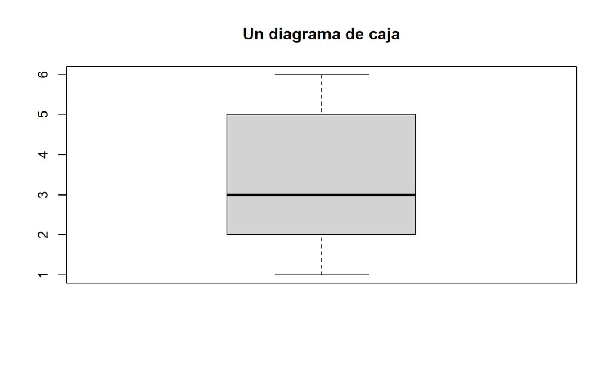

```r
boxplot(dados2, main = "Un diagrama de caja")
```

## La función boxplot

También podemos dibujar diversos diagramas de caja en un mismo gráfico. De este modo, se pueden comparar con mayor facilidad:

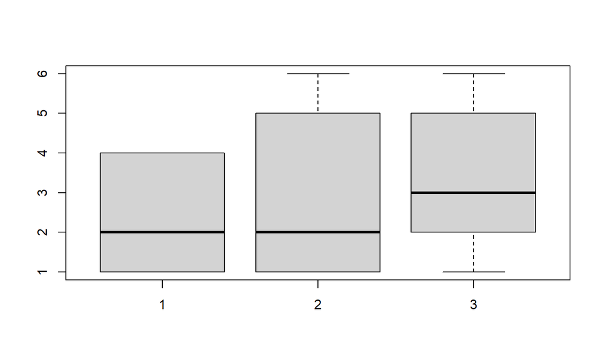

```r
boxplot(dado,dados,dados2)
```

## La función boxplot

Además, podemos dibujar el diagrama de caja de todas las variables de un data frame en un solo paso aplicando la instrucción `boxplot(data.frame)`.

La mayoría de veces, dicho gráfico no será del todo satisfactorio. Dibujar diagramas de factores no tiene sentido alguno. Estos gráficos se pueden manipular incluyendo solo las variables de interés, cambiando los nombres…

Veamos un ejemplo:

## Ejemplo 8

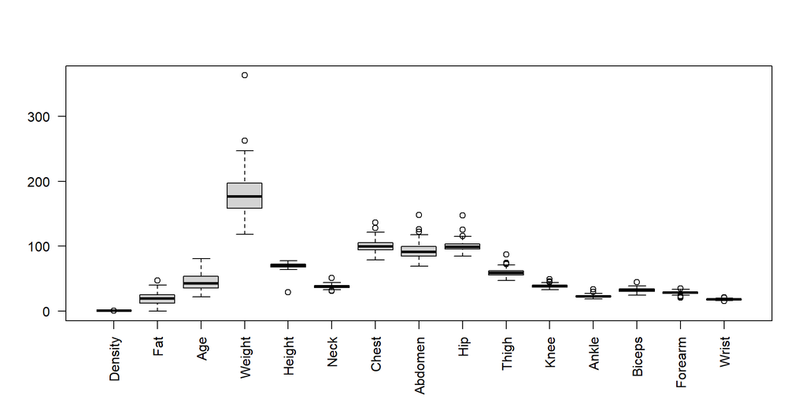

```r
body = read.table("../data/bodyfat.txt", header = TRUE)
boxplot(body,las=2)
```

## Ejemplo 8

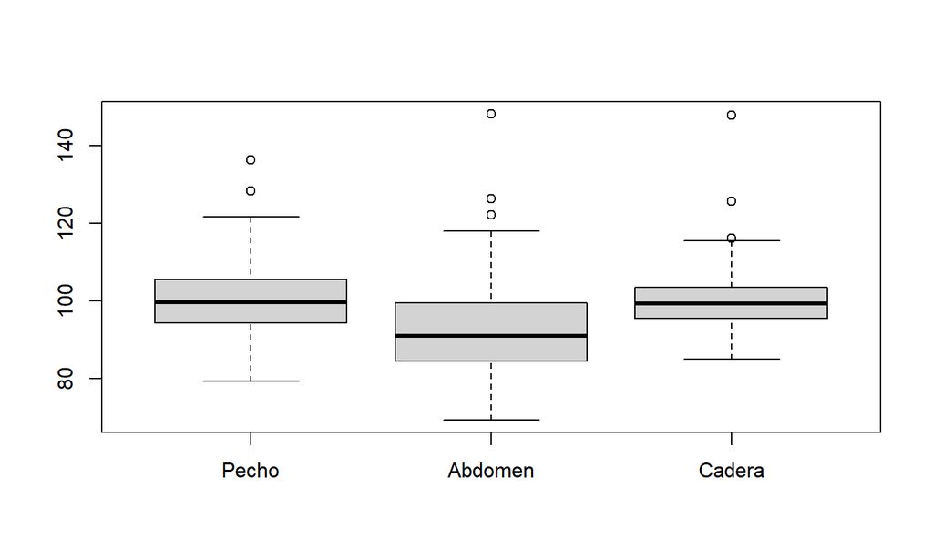

```r
boxplot(body[,7:9], names = c("Pecho", "Abdomen", "Cadera"))
```

## La función boxplot

Agrupar varios diagramas de caja en un solo gráfico tiene por objetivo poder compararlos visualmente, lo cual tiene sentido cuando las variables tienen significados parecidos o cuando comparamos una misma variable de poblaciones distintas.

La mayoría de las veces, querremos comparar diagramas de cajas de una misma variable cuantitativa segmentada por los niveles de un factor.

La sintaxis de la instrucción para dibujar en un único gráfico los diagramas de caja de una variable numérica de un data frame en función de los niveles de un factor del mismo data frame es `boxplot(var.numérica~factor, data = data frame)`

## Ejemplo 9

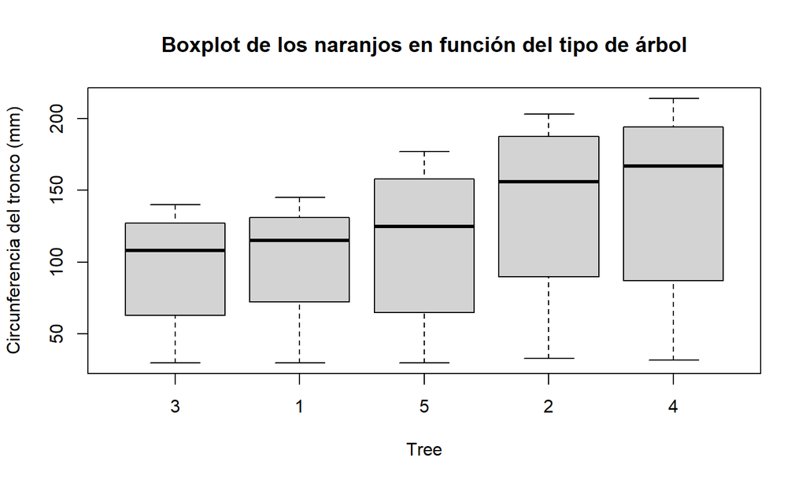

```r
boxplot(circumference~Tree, data = Orange, ylab = "Circunferencia del tronco (mm)",
        main = "Boxplot de los naranjos en función del tipo de árbol")
```

## Parámetros de la función boxplot

Todos los parámetros de la función `plot()` que tengan sentido pueden ser utilizados en los argumentos de la función `boxplot()`.

Aparte, la función `boxplot()` dispone de algunos parámetros específicos, de los cuales mencionaremos:

- `notch` igualado a `TRUE` añade una muesca en la mediana de la caja. Si se da el caso en que las muescas de dos diagramas de cajas no se solapan, entonces con alto grado de confianza, concluimos que las medianas de las poblaciones correspondientes son diferentes.

## Ejemplo 10

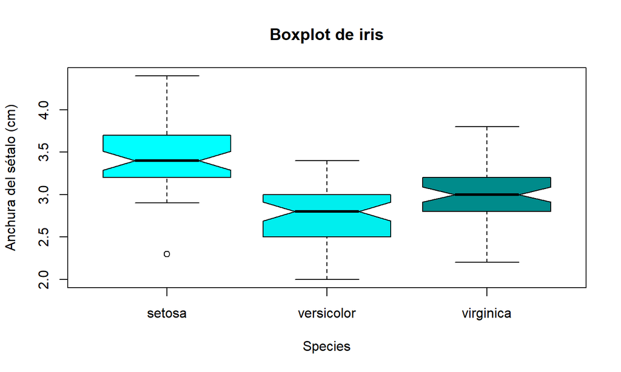

```r
boxplot(Sepal.Width~Species, data = iris, ylab = "Anchura del sétalo (cm)",
        notch = TRUE, col = c("cyan","cyan2","cyan4"),
        main = "Boxplot de iris")
```

## Ejemplo 10

Si quisiéramos marcar de alguna forma en un diagrama de caja, cosa que puede ser muy útil en ocasiones, la media aritmética de la variable correspondiente, podríamos hacerlo mediante la función `points`:

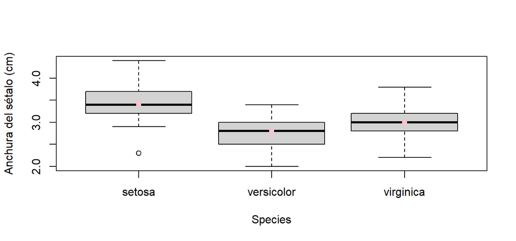

```r
boxplot(Sepal.Width~Species, data = iris, ylab = "Anchura del sétalo (cm)")
medias = aggregate(Sepal.Width~Species, data = iris, FUN = mean)
points(medias, col = "pink", pch = 15)
```

## Ejemplo 10

La primera instrucción del chunk anterior genera el diagrama de cajas de las anchuras de los sépalos en función de la especie. Por su parte, la segunda instrucción lo que hace es calcular las medias aritméticas de las anchuras según la especie. Finalmente, la tercera instrucción lo que hace es añadir al diagrama un punto cuadrado a cada caja en la ordenada correspondiente a su media aritmética.

## La estructura interna de boxplot

Como ya sabemos, podemos estudiar la función interna de algunos objetos con la función `str`.

Dicha función aplicada a un boxplot, nos produce una list. Podéis ver esta list si introducís por consola la siguiente instrucción: `str(boxplot(circumference~Tree, data = Orange))` Destacaremos dos de sus componenetes aquí:

- `stats` nos devuelve los valores \(b_{inf},\ Q_{0.25},\ Q_{0.5},\ Q_{0.75},\ b_{sup}\)
- `out` nos retorna los valores atípicos. En caso de haber diversos diagramas en un plot, la componente `group` nos indica a qué diagramas pertenecen estos ouliers.

## Lección 21: Analis de datos cuantitativos agrupados

## Introducción

Aunque no seamos completamente conscientes de ello, tendemos a agrupar datos cuantitativos constantemente.

Sin ir más lejos, calificamos de excelente a todas las notas que están sobre el 9. También decimos que una persona tiene 20 años cuando se encuentra en el intervalo [20,21). Es decir, cuando ha cumplido los 20 pero aún no tiene los 21.

En estadística, existen innumerables motivos por los cuales nos interesa agrupar los datos cuando estos son cuantitativos. Uno de estos motivos puede ser perfectamente que los datos sean muy heterogéneos. En este caso, nos encontraríamos con que las frecuencias de los valores individuales serían todas muy similares, lo que daría lugar a un diagrama de barras muy difícil de interpretar, tal y como mostramos en el siguiente ejemplo.

## Ejemplo 1

**Ejemplo 1**

Consideremos la siguiente muestra de 24 pesos de estudiantes:

```r
pesos = c(55.2,54.0,55.2,53.7,60.2,53.2,54.6,55.1,51.2,53.2,54.8,52.3,
          56.9,57.0,55.0,53.5,50.9,55.1,53.6,61.2,59.5,50.3,52.7,60.0)
```

El diagrama de barras de sus frecuencias absolutas, tomando como posibles niveles todos los pesos entre su mínimo y máximo se muestra en la siguiente diapositiva.

Como vemos, todas estas frecuencias se encuentran entre 0 y 2, cosa que no nos da mucha información.

## Ejemplo 1

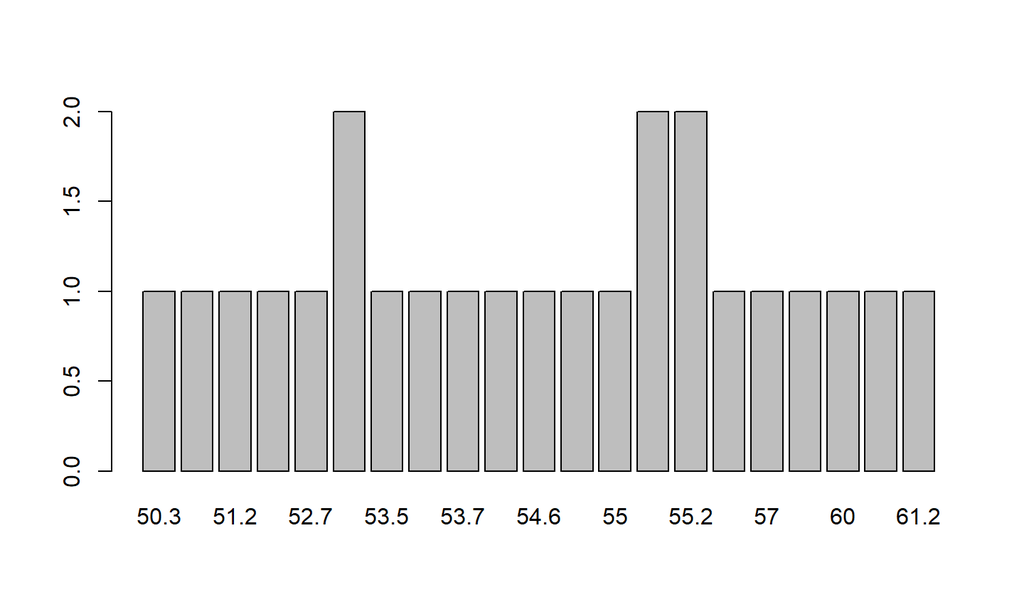

```r
barplot(table(pesos))
```

## Ejemplo 1

En cambio, si dividiésemos todos estos posibles valores que puede tomar la variable cuantitativa en intervalos y tomásemos como sus frecuencias las de todos los valores que caen en dicho intervalo, la cosa cambia.

En este caso, sería mucho más fácil interpretar los resultados, ya que estos darán mucha más información. Más adelante veremos como crear estos intervalos.

```r
hist(pesos, breaks = 6, right = FALSE, main = "", ylab = "Frecuencia", xlab = "pesos")
```

## Ejemplo 1

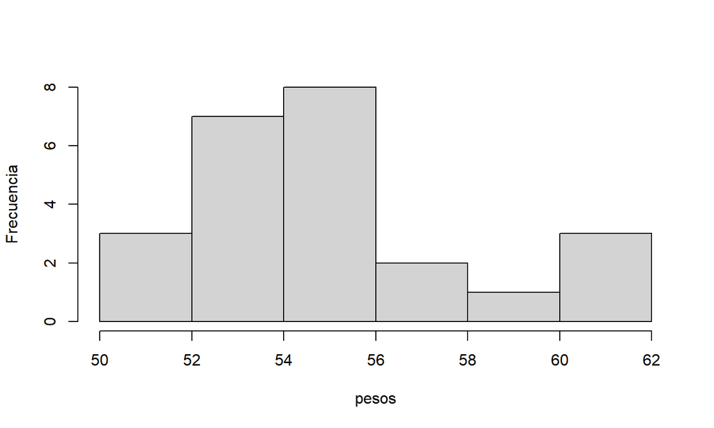

## Introducción

Otro de los motivos por el que necesitamos muchas veces agrupar los datos cuantitativos es porque, como ya dijimos en temas anteriores, la precisión infinita no existe. Por tanto, esta imposibilidad de medir de manera exacta muchas de las magnitudes continuas (tiempo, peso, altura…) nos obliga a trabajar con aproximaciones o redondeos de valores reales y que cada uno de estos represente todo un intervalo de posibles valores.

## Introducción

- Cuando los datos son continuos, su redondeo ya define un agrupamiento debido a la inexistencia de precisión infinita
- Cuando los datos son discretos, pero con un número considerablemente grande de posibles valores
- Cuando tenemos muchísimos datos y estamos interesados en estudiar las frecuencias de sus valores

## Lección 22: Cómo agrupar datos

## Los 4 pasos

Antes de estudiar unos datos agrupados, hay que, obviamente, agruparlos. Este proceso consta de 4 pasos:

No hay una forma de agrupar datos mejor que otra. Eso sí, cada uno de los diferentes agrupamientos para un conjunto de datos podría sacar a la luz características diferentes del conjunto.

## La función hist()

La función de R por excelencia para estudiar datos agrupados es `hist`. Dicha función implementa los 4 pasos del proceso.

Si le indicamos como argumentos el vector de datos y el número de intervalos que deseamos, o bien el método para determinarlo (cosa que veremos a continuación), la función agrupará los datos en el número de clases que le hemos introducido, más o menos. Eso sí, sin control de ningún tipo por nuestra parte sobre los intervalos que produce.

Esto puede venirnos bien en algunos casos, pero no en otros.

## Cálculo del número de clases

En este tema explicaremos una receta para agrupar datos. Lo dicho, ni mejor ni peor que el resto.

Lo primero es establecer el número \(k\) de clases en las que vamos a dividir nuestros datos. Podemos decidir en función de nuestros intereses o podemos hacer uso de alguna de las reglas existentes. Destacaremos las más populares. Sea \(n\) el número total de datos de la muestra

- : \(k = \lceil\sqrt{n}\ \rceil\)
- : \(k = \lceil 1+\log_{2}(n)\rceil\)

## Cálculo del número de clases

- : Se determina primero la , \(A_S\) de las clases \[A_S = 3.5\cdot\tilde{s}\cdot n^{-\frac{1}{3}}\] donde \(\tilde{s}\) es la desviación típica muestral. Luego se toma \[k = \left\lceil \frac{\max(x)-\min(x)}{A_S}\right\rceil\]

## Cálculo del número de clases

- : Se determina primero la , \(A_{FD}\) de las clases \[A_{FD} = 2\cdot(Q_{0.75}-Q_{0.25})\cdot n^{-\frac{1}{3}}\] (donde, recordemos, \(Q_{0.75}-Q_{0.25}\), es el rango intercuantílico) y entonces \[k = \left\lceil \frac{\max(x)-\min(x)}{A_{FD}}\right\rceil\]

Si os fijáis, las dos primeras solo dependen de \(n\), mientras que las dos últimas también tienen en cuenta, de formas diferentes, la dispersión de los datos. De nuevo, no hay ninguna mejor que las demás. Pero sí puede ocurrir que métodos diferentes den lugar a la observación de características diferentes en los datos.

## Cálculo del número de clases con R

Las instrucciones para llevar a cabo las 3 últimas reglas con R son, respectivamente,

- `nclass.Sturges`
- `nclass.scott`
- `nclass.FD`

Puede ocurrir que las difrentes reglas den valores diferentes, o no.

## Decidiendo la amplitud

Una vez determinado \(k\), hay que decidir su amplitud.

La forma más fácil y la que nosotros utilizaremos por defecto es que la amplitud de todos los intervalos sea la misma, \(A\). Esta forma no es la única.

Para calcular \(A\), lo que haremos será dividir el rango de los datos entre \(k\), el número de clases, y redondearemos por exceso a un valor de la precisión de la medida.

Si se da el improbable caso en que el cociente de exacto, tomaremos como \(A\) ese cociente más una unidad de precisión.

## Extremos de los intervalos

Es la hora de calcular los extremos de los intervalos. Nosotros tomaremos estos intervalos siempre cerrados por su izquierda y abiertos por la derecha, debido a que esta es la forma en que R los construye y porque es así como se utilizan en Teoría de Probabilidades al definir la distribución de una variable aleatoria discreta y también en otras muchas situaciones cotidianas.

Utilizaremos la siguiente notación \[[L_1,L_2),[L_2,L_3),\dots,[L_k,L_{k+1})\]

donde los \(L_i\) denotan los extremos de los intervalos. Estos se calculan de la siguiente forma:

\[L_1 = \min(x)-\frac{1}{2}\cdot \text{precisión}\]

## Extraemos de los intervalos

A partir de \(L_1\), el resto de intervalos se obtiene de forma recursiva: \[L_2 = L_1 + A\] \[L_3 = L_2 + A\] \[\vdots\] \[L_{k+1} = L_k+A\]

Si nos fijamos bien, los extremos forman una progresión aritmética de salto \(A\): \[L_{i} = L_{1}+(i-1)A,\qquad i=2,\dots,k+1\]

De esta forma garantizamos que los extremos de los intervalos nunca coincidan con valores del conjunto de datos, puesto que tinen una precisión mayor.

## Marca de clase

Solo nos queda determinar la , \(X_i\), de cada intervalo \([L_i,L_{i+1})\).

Este no es más que un valor del intervalo que utilizaremos para identificar la clase y para calcular algunos estadísticos.

Genralmente, \[X_i = \frac{L_i+L_{i+1}}{2}\] es decir, \(X_i\) será el punto medio del intervalo, para así garantizar que el error máximo cometido al describir cualquier elemento del intervalo por medio de su marca de clase sea mínimo o igual a la mitad de la amplitud del respectivo intervalo.

## Marca de clase

Es sencillo concluir que, al tener todos los intervalos amplitud \(A\), la distancia entre \(X_i\) y \(X_{i+1}\) tambien será \(A\). Por consiguiente,

\[X_{i} = X_1+ (i-1)A,\qquad i=2,\dots,k\]

donde \[X_1 = \frac{L_1+L_2}{2}\]

## Ejemplo

**Ejemplo 2**

Vamos a considerar el conjunto de datos de `datacrab`. Para nuestro estudio, trabajaremos únicamente con la variable `width`.

Llevaremos a cabo los 4 pasos explicados con anterioridad: cálculo del número de intervalos, determinación de la amplitud, cálculo de los extremos y las marcas de clase.

## Solución

En primer lugar, cargamos los datos en un data frame:

```r
crabs = read.table("../data/datacrab.txt", header = TRUE)
str(crabs)
```

```
'data.frame':   173 obs. of  6 variables:
 $ input : int  1 2 3 4 5 6 7 8 9 10 ...
 $ color : int  3 4 2 4 4 3 2 4 3 4 ...
 $ spine : int  3 3 1 3 3 3 1 2 1 3 ...
 $ width : num  28.3 22.5 26 24.8 26 23.8 26.5 24.7 23.7 25.6 ...
 $ satell: int  8 0 9 0 4 0 0 0 0 0 ...
 $ weight: int  3050 1550 2300 2100 2600 2100 2350 1900 1950 2150 ...
```

```r
cw = crabs$width
```

A continuación, definimos la variable `cw` que contiene los datos de la variable `width`.

## Solución

Calculemos el número de clases según las diferentes reglas que hemos visto:

- Regla de la raíz cuadrada:

```r
n = length(cw)
k1 = ceiling(sqrt(n))
k1
```

```
[1] 14
```

- Regla de Sturges:

```r
k2 = ceiling(1+log(n,2))
k2
```

```
[1] 9
```

## Solución

- Regla de Scott:

```r
As = 3.5*sd(cw)*n^(-1/3) #Amplitud teórica
k3 = ceiling(diff(range(cw))/As)
k3
```

```
[1] 10
```

- Regla de Freedman-Diaconis:

```r
#Amplitud teórica
Afd = 2*(quantile(cw,0.75, names = FALSE)-
           quantile(cw,0.25,names = FALSE))*n^(-1/3)
k4 = ceiling(diff(range(cw))/Afd)
k4
```

```
[1] 13
```

## Solución

Podemos comprobar nuestros 3 últimos resultados con R:

```r
nclass.Sturges(cw)
```

```
[1] 9
```

```r
nclass.scott(cw)
```

```
[1] 10
```

```r
nclass.FD(cw)
```

```
[1] 13
```

De momento, vamos a seguir la Regla de Scott. Es decir, vamos a considerar 10 intervalos.

## Solución

A continuación, debemos elegir la amplitud de los intervalos.

```r
A = diff(range(cw)) / 10
A
```

```
[1] 1.25
```

Como nuestros datos están expresados en mm con una precisión de una cifra decimal, debemos redondear por exceso a un cifra decimal el resultado obtenido. Por lo tanto, nuestra amplitud será de

```r
A = 1.3
```

Recordad que si el cociente nos hubiera dado un valor exacto con respecto a la precisión, tendríamos que haberle sumado una unidad de precisión.

## Solución

Ahora nos toca calcular los extremos \(L_1,\dots,L_{11}\) de los intervalos.

Recordad que nuestros intervalos tendrán la siguiente forma:

\[[L_1,L_2),\ \dots,\ [L_{10},L_{11})\] Calculamos el primer extremo:

```r
L1 = min(cw)-1/2*0.1
L1
```

```
[1] 20.95
```

donde 0.1 es nuestra precisión (décimas de unidad, en este caso).

## Solución

Y, el resto de extremos se calculan del siguiente modo:

```r
L2 = L1 + A
L3 = L2 + A
L4 = L3 + A
L5 = L4 + A
L6 = L5 + A
L7 = L6 + A
L8 = L7 + A
L9 = L8 + A
L10 = L9 + A
L11 = L10 + A
L = c(L1,L2,L3,L4,L5,L6,L7,L8,L9,L10,L11)
L
```

```
 [1] 20.95 22.25 23.55 24.85 26.15 27.45 28.75 30.05 31.35 32.65 33.95
```

## Solución

O bien, si queremos facilitarnos el trabajo, también los podemos calcular mucho más rápido del siguiente modo:

```r
L = L1 + A*(0:10)
L
```

```
 [1] 20.95 22.25 23.55 24.85 26.15 27.45 28.75 30.05 31.35 32.65 33.95
```

Así, nuestros intervalos serán los siguientes:

\[[20.95,22.25),\ [22.25,23.55),\ [23.55,24.85),\ [24.85,26.15),\ [26.15,27.45),\] \[[27.45,28.75),\ [28.75,30.05),\ [30.05,31.35),\ [31.35,32.65),\ [32.65,33.95)\]

## Solución

Y hemos llegado al úlitmo paso: calcular las marcas de clase.

Recordemos que \(X_i = \frac{L_{i}+L_{i+1}}{2} \quad\forall i=1,\dots,10\)

Empecemos calculando \(X_1\)

```r
X1 = (L[1]+L[2])/2
X1
```

```
[1] 21.6
```

## Solución

Y, el resto de marcas de clase se calculan del siguiente modo:

```r
X2 = X1 + A
X3 = X2 + A
X4 = X3 + A
X5 = X4 + A
X6 = X5 + A
X7 = X6 + A
X8 = X7 + A
X9 = X8 + A
X10 = X9 + A
X = c(X1,X2,X3,X4,X5,X6,X7,X8,X9,X10)
X
```

```
 [1] 21.6 22.9 24.2 25.5 26.8 28.1 29.4 30.7 32.0 33.3
```

## Solución

O bien, si queremos facilitarnos el trabajo, también los podemos calcular mucho más rápido como sucesión:

```r
X = X1 + A*(0:9)
X
```

```
 [1] 21.6 22.9 24.2 25.5 26.8 28.1 29.4 30.7 32.0 33.3
```

o también, como punto medio del intervalo

```r
X = (L[1:length(L)-1]+L[2:length(L)])/2
X
```

```
 [1] 21.6 22.9 24.2 25.5 26.8 28.1 29.4 30.7 32.0 33.3
```

## Ejercicio

Repetir este proceso para el número de clases obtenido con

- la regla de la raíz
- la regla de Sturges
- la regla de Freedman-Diaconis

## Lección 23: Agrupando datos con R

## Agrupando los datos con R

Al agrupar los datos, lo que hacemos es convertir nuestra variable cuantitativa en un factor cuyos niveles son las clases en que ha sido dividida e identificamos cada dato con su clase.

A la hora de etiquetar los niveles, podemos elegir 3 codificaciones:

- Los intervalos
- Las marcas de clase (el punto medio de cada intervalo)
- El número de orden de cada intervalo

## La función cut

Esta función es la básica en R para agrupar un vector de datos numéricos y codificar sus valores con clases a las que pertenecen.

Su sintaxis básica es

`cut(x, breaks=..., labels=..., right=...)`

- `x` es el vector numérico, nuestra variable cuantitativa
- `breaks` puede ser un vector numérico formado por los extremos de los intervalos en los que queremos agrupar nuestros datos y que habremos calculado previamente. También puede ser un número \(k\), en cuyo caso R agrupa los datos en \(k\) clases. Para este caso, R divide el intervalo comprendido entre los valores mínimo y máximo de \(x\) en \(k\) intervalos y, a continuación, desplaza ligeramente el extremo inferior del primer intervalo a la izquierda y el extremo del último, a la derecha.

## La función cut

- `labels` es un vector con las etiquetas de los intervalos. Su valor por defecto es utilizar la etiqueta de los mismos intervalos. Si especificamos `labels = FALSE`, obtendremos los intervalos etiquetados por medio de los números naturales correlativos, empezando por 1. Para utilizar como etiqueta las marcas de clase o cualquier otra codificación, hay que entrarlo como valor de este parámetro.
- `right` es un parámetro que igualadao a `FALSE` hace que los intervalos que consideremos sean cerrados por la izquierda y abiertos por la derecha. Este no es su valor por defecto.
- `include.lowest` igualdo a `TRUE` combinado con `right = FALSE` hace que el último intervalo sea cerrado. Puede sernos útil en algunos casos.

## La función cut

En cualquier caso, el resultado de la función `cut` es una lista con los elementos del vector original codificados con las etiquetas de las clases a las que pertenecen. Bien puede ser un factor o un vector.

## Lección 24: Estudio de datos agrupados

## Frecuencias

Una primera consideración es tratar las clases obtenidas en el paso anterior como los niveles de una variable ordinal y calcular sus frecuencias.

- La frecuencia absoluta de una clase será el número de datos originales que pertenecen a la clase
- La frecuencia absoluta acumulada de una clase será el número de datos que pertenecen a dicha clase o alguna de las anteriores

## Tabla de frecuencias

Normalmente, las frecuencias de un conjunto de datos agrupados se suele representar de la siguiente forma

| Intervalos | \(X_j\) | \(n_j\) | \(N_j\) | \(f_j\) | \(F_j\) |
| --- | --- | --- | --- | --- | --- |
| \([L_1,L_2)\) | \(X_1\) | \(n_1\) | \(N_1\) | \(f_1\) | \(F_1\) |
| \([L_2,L_3)\) | \(X_2\) | \(n_2\) | \(N_2\) | \(f_2\) | \(F_2\) |
| \(\vdots\) | \(\vdots\) | \(\vdots\) | \(\vdots\) | \(\vdots\) | \(\vdots\) |
| \([L_k,L_{k+1})\) | \(X_k\) | \(n_k\) | \(N_k\) | \(f_k\) | \(F_k\) |

## La función hist

El cálculo de las frecuencias con R podemos hacerlo mediante las funciones `table`, `prop.table` y `cumsum`.

También podemos utilizar la función `hist`, que internamente genera una list cuya componente `count` es el vector de frecuencias absolutas de las clases. Por consiguiente, para calcular estas frecuencias, podemos utilizar la sintaxis

`hist(x, breaks=..., right=FALSE, plot=FALSE)$count`

Conviene igualar el parámetro `breaks` al vector de los extremos del intervalo debido a que `cut` y `hist` hacen uso de diferentes métodos para agrupar los datos cuando se especifica solamente el número \(k\) de clases.

El resultado de `hist` incluye la componente `mids` que contiene el vector de puntos medios de los intervalos, es decir, nuestras marcas de clase.

## Tabla de frecuencias con R

Podemos automatizar el cálculo de la ya tan mencionada tabla de frecuencias, utilizando las dos funciones que mostramos a continuación.

La primera sirve en el caso en que vayamos a tomar todas las clases de la misma amplitud. Sus parámetros son: \(x\), el vector con los datos cuantitativos; \(k\), el número de clases; \(A\), su amplitud; y \(p\), la precisión de los datos (p = 1 si la precisión son unidades, p = 0.1 si la precisión son décimas de unidad…).

Por su parte, la segunda es para cuando conocemos los extremos de las clases. Sus parámetros son: \(x\), el vector con los datos cuantitativos; \(L\), el vector de extremos de clases; y \(V\) , un valor lógico, que ha de ser `TRUE` si queremos que el último intervalo sea cerrado, y `FALSE` en caso contrario.

## Tablas de frecuencias con R

```r
#Primera función
TablaFrecs = function(x,k,A,p){
  L = min(x)-p/2+A*(0:k)
  x_cut = cut(x, breaks = L, right=FALSE)
  intervals = levels(x_cut)
  mc = (L[1]+L[2])/2+A*(0:(k-1))
  Fr.abs = as.vector(table(x_cut))
  Fr.rel = round(Fr.abs/length(x),4)
  Fr.cum.abs = cumsum(Fr.abs)
  Fr.cum.rel = cumsum(Fr.rel)
  tabla = data.frame(intervals, mc, Fr.abs, Fr.cum.abs, Fr.rel, Fr.cum.rel)
  tabla
  }
```

## Tablas de frecuencias

```r
TablaFrecs.L = function(x,L,V){
  x_cut = cut(x, breaks=L, right=FALSE, include.lowest=V)
  intervals = levels(x_cut)
  mc = (L[1:(length(L)-1)]+L[2:length(L)])/2
  Fr.abs = as.vector(table(x_cut))
  Fr.rel = round(Fr.abs/length(x),4)
  Fr.cum.abs = cumsum(Fr.abs)
  Fr.cum.rel = cumsum(Fr.rel)
  tabla = data.frame(intervals, mc, Fr.abs, Fr.cum.abs, Fr.rel, Fr.cum.rel)
  tabla
  }
```

## Enunciado

**Ejemplo 2 (continuación)**

Siguiendo con el ejemplo de las anchuras de los cangrejos, vamos a calcular sus tablas de frecuencias haciendo uso de todo lo aprendido anteriormente.

## Solución

La tabla queda del siguiente modo:

| Intervalos | \(X_j\) | \(n_j\) | \(N_j\) | \(f_j\) | \(F_j\) |
| --- | --- | --- | --- | --- | --- |
| [20.95, 22.25) | 21.6 | 2 | 2 | 0.0116 | 0.0116 |
| [22.25, 23.55) | 22.9 | 14 | 16 | 0.0809 | 0.0925 |
| [23.55, 24.85) | 24.2 | 27 | 43 | 0.1561 | 0.2486 |
| [24.85, 26.15) | 25.5 | 44 | 87 | 0.2543 | 0.5029 |
| [26.15, 27.45) | 26.8 | 34 | 121 | 0.1965 | 0.6994 |
| [27.45, 28.75) | 28.1 | 31 | 152 | 0.1792 | 0.8786 |

## Solución

| Intervalos | \(X_j\) | \(n_j\) | \(N_j\) | \(f_j\) | \(F_j\) |
| --- | --- | --- | --- | --- | --- |
| [28.75, 30.05) | 29.4 | 15 | 167 | 0.0867 | 0.9653 |
| [30.05, 31.35) | 30.7 | 3 | 170 | 0.0173 | 0.9826 |
| [31.35, 32.65) | 32 | 2 | 172 | 0.0116 | 0.9942 |
| [32.65, 33.95) | 33.3 | 1 | 173 | 0.0058 | 1 |

## Solución

Y, ahora, lo haremos con las funciones que os hemos proporcionado:

```r
TablaFrecs(cw,10,1.3,0.1)
```

```
     intervals   mc Fr.abs Fr.cum.abs Fr.rel Fr.cum.rel
1  [20.9,22.2) 21.6      2          2 0.0116     0.0116
2  [22.2,23.6) 22.9     14         16 0.0809     0.0925
3  [23.6,24.9) 24.2     27         43 0.1561     0.2486
4  [24.9,26.1) 25.5     44         87 0.2543     0.5029
5  [26.1,27.4) 26.8     34        121 0.1965     0.6994
6  [27.4,28.8) 28.1     31        152 0.1792     0.8786
7    [28.8,30) 29.4     15        167 0.0867     0.9653
8    [30,31.4) 30.7      3        170 0.0173     0.9826
9  [31.4,32.6) 32.0      2        172 0.0116     0.9942
10   [32.6,34) 33.3      1        173 0.0058     1.0000
```

## Solución

```r
TablaFrecs.L(cw,L,FALSE)
```

```
     intervals   mc Fr.abs Fr.cum.abs Fr.rel Fr.cum.rel
1  [20.9,22.2) 21.6      2          2 0.0116     0.0116
2  [22.2,23.6) 22.9     14         16 0.0809     0.0925
3  [23.6,24.9) 24.2     27         43 0.1561     0.2486
4  [24.9,26.1) 25.5     44         87 0.2543     0.5029
5  [26.1,27.4) 26.8     34        121 0.1965     0.6994
6  [27.4,28.8) 28.1     31        152 0.1792     0.8786
7    [28.8,30) 29.4     15        167 0.0867     0.9653
8    [30,31.4) 30.7      3        170 0.0173     0.9826
9  [31.4,32.6) 32.0      2        172 0.0116     0.9942
10   [32.6,34) 33.3      1        173 0.0058     1.0000
```

Fijaos que los intervalos no terminan de ser los que hemos calculado nosotros, pero eso se debe a como funciona la función `cut`.

## Enunciado

**Ejemplo 3**

Se han recogido las notas de un examen de historia a los 100 alumnos de primero de bachillerato de un instituto.

Vamos a hacer uso de todo lo aprendido para obtener la mayor información posible utilizando las funciones `cut` e `hist` y también, las proporcionadas por nosotros.

## Solución

Los resultados obtenidos en la encuesta han sido:

```r
notas
```

```
  [1]  7 10  2  2  6  2  5  4  9  2  7  5  1  7  0  3 10  2 10  4  1  4  5  4  0
 [26]  5 10  4  3  0  7  5 10  3  4  8  1  9  3  7  9  1  9 10  5 10 10  9  5  0
 [51]  3  1  3  2  0  6  6  4  7  4  7  3  9  0  7  0  3  0  3  3  1  4 10  9  1
 [76]  4  0  6 10  0 10  1  0  2  6  4  8  2  3  7  7  3  3  8  2  6  6  2  8  9
```

## Solución

Vamos a agrupar las notas en los siguientes intervalos:

\[[0,5),\ [5,7),\ [7,9),\ [9,10]\]

Claramente, estos 4 intervalos no tienen la misma amplitud.

Fijémonos también en que el último intervalo está cerrado por la derecha.

## Solución

```r
#Definimos vector de extremos
L = c(0,5,7,9,10)
#Definimos notas1 como el resultado de la codificación en
#intervalos utilizando como etiquetas los propios intervalos
notas1 = cut(notas, breaks = L, right = FALSE, include.lowest = TRUE)
notas1
```

```
  [1] [7,9)  [9,10] [0,5)  [0,5)  [5,7)  [0,5)  [5,7)  [0,5)  [9,10] [0,5)
 [11] [7,9)  [5,7)  [0,5)  [7,9)  [0,5)  [0,5)  [9,10] [0,5)  [9,10] [0,5)
 [21] [0,5)  [0,5)  [5,7)  [0,5)  [0,5)  [5,7)  [9,10] [0,5)  [0,5)  [0,5)
 [31] [7,9)  [5,7)  [9,10] [0,5)  [0,5)  [7,9)  [0,5)  [9,10] [0,5)  [7,9)
 [41] [9,10] [0,5)  [9,10] [9,10] [5,7)  [9,10] [9,10] [9,10] [5,7)  [0,5)
 [51] [0,5)  [0,5)  [0,5)  [0,5)  [0,5)  [5,7)  [5,7)  [0,5)  [7,9)  [0,5)
 [61] [7,9)  [0,5)  [9,10] [0,5)  [7,9)  [0,5)  [0,5)  [0,5)  [0,5)  [0,5)
 [71] [0,5)  [0,5)  [9,10] [9,10] [0,5)  [0,5)  [0,5)  [5,7)  [9,10] [0,5)
 [81] [9,10] [0,5)  [0,5)  [0,5)  [5,7)  [0,5)  [7,9)  [0,5)  [0,5)  [7,9)
 [91] [7,9)  [0,5)  [0,5)  [7,9)  [0,5)  [5,7)  [5,7)  [0,5)  [7,9)  [9,10]
Levels: [0,5) [5,7) [7,9) [9,10]
```

## Solución

```r
#Definimos las marcas de clase
MC = (L[1:length(L)-1]+L[2:length(L)])/2
#Definimos notas2 como el resultado de la codificación en
#intervalos utilizando como etiquetas las marcas de clase
notas2 = cut(notas, breaks = L, labels = MC, right = FALSE,
             include.lowest = TRUE)
notas2
```

```
  [1] 8   9.5 2.5 2.5 6   2.5 6   2.5 9.5 2.5 8   6   2.5 8   2.5 2.5 9.5 2.5
 [19] 9.5 2.5 2.5 2.5 6   2.5 2.5 6   9.5 2.5 2.5 2.5 8   6   9.5 2.5 2.5 8
 [37] 2.5 9.5 2.5 8   9.5 2.5 9.5 9.5 6   9.5 9.5 9.5 6   2.5 2.5 2.5 2.5 2.5
 [55] 2.5 6   6   2.5 8   2.5 8   2.5 9.5 2.5 8   2.5 2.5 2.5 2.5 2.5 2.5 2.5
 [73] 9.5 9.5 2.5 2.5 2.5 6   9.5 2.5 9.5 2.5 2.5 2.5 6   2.5 8   2.5 2.5 8
 [91] 8   2.5 2.5 8   2.5 6   6   2.5 8   9.5
Levels: 2.5 6 8 9.5
```

## Solución

```r
#Definimos notas3 como el resultado de la codificación en
#intervalos utilizando como etiquetas la posición ordenada
#del intervalo (1, 2, 3 o 4)
notas3 = cut(notas, breaks = L, labels = FALSE, right = FALSE,
             include.lowest = TRUE)
notas3
```

```
  [1] 3 4 1 1 2 1 2 1 4 1 3 2 1 3 1 1 4 1 4 1 1 1 2 1 1 2 4 1 1 1 3 2 4 1 1 3 1
 [38] 4 1 3 4 1 4 4 2 4 4 4 2 1 1 1 1 1 1 2 2 1 3 1 3 1 4 1 3 1 1 1 1 1 1 1 4 4
 [75] 1 1 1 2 4 1 4 1 1 1 2 1 3 1 1 3 3 1 1 3 1 2 2 1 3 4
```

## Solución

```r
#Definimos notas4 como el resultado de la codificación en
#intervalos utilizando como etiquetas Susp, Aprob, Not y Exc
notas4 = cut(notas, breaks = L, labels = c("Susp", "Aprob", "Not", "Exc"),
             right = FALSE, include.lowest = TRUE)
notas4
```

```
  [1] Not   Exc   Susp  Susp  Aprob Susp  Aprob Susp  Exc   Susp  Not   Aprob
 [13] Susp  Not   Susp  Susp  Exc   Susp  Exc   Susp  Susp  Susp  Aprob Susp
 [25] Susp  Aprob Exc   Susp  Susp  Susp  Not   Aprob Exc   Susp  Susp  Not
 [37] Susp  Exc   Susp  Not   Exc   Susp  Exc   Exc   Aprob Exc   Exc   Exc
 [49] Aprob Susp  Susp  Susp  Susp  Susp  Susp  Aprob Aprob Susp  Not   Susp
 [61] Not   Susp  Exc   Susp  Not   Susp  Susp  Susp  Susp  Susp  Susp  Susp
 [73] Exc   Exc   Susp  Susp  Susp  Aprob Exc   Susp  Exc   Susp  Susp  Susp
 [85] Aprob Susp  Not   Susp  Susp  Not   Not   Susp  Susp  Not   Susp  Aprob
 [97] Aprob Susp  Not   Exc
Levels: Susp Aprob Not Exc
```

## Solución

El resultado de `cut` ha sido, en cada caso, una lista con los elementos del vector original codificados con las etiquetas de las clases a las que pertenecen.

Las dos primeras aplicaciones de la función `cut` han producido factores (cuyos niveles son los intervalos y las marcas de clase, respectivamente, en ambos casos ordenados de manera natural), mientras que aplicándole `labels = FALSE` hemos obtenido un vector.

## Solución

¿Qué habría ocurrido si le hubiéramos pedido a R que cortase los datos en 4 intervalos?

Pues en este caso no nos hubiera servido de mucho, sobre todo porque la amplitud de nuestros intervalos era, desde buen inicio, diferente.

## Solución

```r
cut(notas, breaks = 4, right = FALSE, include.lowest = TRUE)
```

```
  [1] [5,7.5)     [7.5,10]    [-0.01,2.5) [-0.01,2.5) [5,7.5)     [-0.01,2.5)
  [7] [5,7.5)     [2.5,5)     [7.5,10]    [-0.01,2.5) [5,7.5)     [5,7.5)
 [13] [-0.01,2.5) [5,7.5)     [-0.01,2.5) [2.5,5)     [7.5,10]    [-0.01,2.5)
 [19] [7.5,10]    [2.5,5)     [-0.01,2.5) [2.5,5)     [5,7.5)     [2.5,5)
 [25] [-0.01,2.5) [5,7.5)     [7.5,10]    [2.5,5)     [2.5,5)     [-0.01,2.5)
 [31] [5,7.5)     [5,7.5)     [7.5,10]    [2.5,5)     [2.5,5)     [7.5,10]
 [37] [-0.01,2.5) [7.5,10]    [2.5,5)     [5,7.5)     [7.5,10]    [-0.01,2.5)
 [43] [7.5,10]    [7.5,10]    [5,7.5)     [7.5,10]    [7.5,10]    [7.5,10]
 [49] [5,7.5)     [-0.01,2.5) [2.5,5)     [-0.01,2.5) [2.5,5)     [-0.01,2.5)
 [55] [-0.01,2.5) [5,7.5)     [5,7.5)     [2.5,5)     [5,7.5)     [2.5,5)
 [61] [5,7.5)     [2.5,5)     [7.5,10]    [-0.01,2.5) [5,7.5)     [-0.01,2.5)
 [67] [2.5,5)     [-0.01,2.5) [2.5,5)     [2.5,5)     [-0.01,2.5) [2.5,5)
 [73] [7.5,10]    [7.5,10]    [-0.01,2.5) [2.5,5)     [-0.01,2.5) [5,7.5)
 [79] [7.5,10]    [-0.01,2.5) [7.5,10]    [-0.01,2.5) [-0.01,2.5) [-0.01,2.5)
 [85] [5,7.5)     [2.5,5)     [7.5,10]    [-0.01,2.5) [2.5,5)     [5,7.5)
 [91] [5,7.5)     [2.5,5)     [2.5,5)     [7.5,10]    [-0.01,2.5) [5,7.5)
 [97] [5,7.5)     [-0.01,2.5) [7.5,10]    [7.5,10]
Levels: [-0.01,2.5) [2.5,5) [5,7.5) [7.5,10]
```

## Solución

R ha repartido los datos en 4 intervalos de longitud 2.5, y ha desplazado ligeramente a la izquierda el extremo izquierdo del primer intervalo.

## Solución

Trabajaremos ahora con `notas4` y calcularemos sus frecuencias:

```r
table(notas4) #Fr. Abs
```

```
notas4
 Susp Aprob   Not   Exc
   53    14    14    19
```

```r
prop.table(table(notas4)) #Fr. Rel
```

```
notas4
 Susp Aprob   Not   Exc
 0.53  0.14  0.14  0.19
```

## Solución

```r
cumsum(table(notas4)) #Fr. Abs. Cum
```

```
 Susp Aprob   Not   Exc
   53    67    81   100
```

```r
cumsum(prop.table(table(notas4))) #Fr. Rel. Cum
```

```
 Susp Aprob   Not   Exc
 0.53  0.67  0.81  1.00
```

## Solución

Podríamos haber obtenido todo lo anterior haciendo uso de la función `hist`.

```r
notasHist = hist(notas, breaks = L, right = FALSE, include.lowest = TRUE,
                 plot = FALSE)
FAbs = notasHist$count
FRel = prop.table(FAbs)
FAbsCum = cumsum(FAbs)
FRelCum = cumsum(FRel)
```

## Solución

Ahora ya podemos crear un data frame con todas estas frecuencias:

```r
intervalos = c("[0,5)","[5,7)","[7,9)","[9,10]")
calificacion = c("Suspenso", "Aprobado", "Notable", "Excelente")
marcas = notasHist$mids
tabla.Fr = data.frame(intervalos,calificacion,marcas,FAbs,FAbsCum,
                      FRel,FRelCum)
tabla.Fr
```

```
  intervalos calificacion marcas FAbs FAbsCum FRel FRelCum
1      [0,5)     Suspenso    2.5   53      53 0.53    0.53
2      [5,7)     Aprobado    6.0   14      67 0.14    0.67
3      [7,9)      Notable    8.0   14      81 0.14    0.81
4     [9,10]    Excelente    9.5   19     100 0.19    1.00
```

## Solución

O bien, podríamos haber utilizado las funciones que os hemos proporcionado:

```r
TablaFrecs.L(notas, L, TRUE)
```

```
  intervals  mc Fr.abs Fr.cum.abs Fr.rel Fr.cum.rel
1     [0,5) 2.5     53         53   0.53       0.53
2     [5,7) 6.0     14         67   0.14       0.67
3     [7,9) 8.0     14         81   0.14       0.81
4    [9,10] 9.5     19        100   0.19       1.00
```

## Lección 25: Estadísticos para datos agrupados

## Estadísticos para datos agrupados

Al tener una muestra de datos numéricos, conviene calcular los antes de realizar los agrupamientos, puesto que de lo contrario podemos perder información.

No obstante, hay situaciones en que los datos los obtenemos ya agrupados. En estos casos, aún sigue siendo posible calcular los estadísticos y utilizarlos como aproximaciones de los estadísticos de los datos “reales”, los cuales no conocemos.

## Estadísticos para datos agrupados

La media \(\bar{x}\), la varianza, \(s^2\), la varianza muestral, \(\tilde{s}^2\), la desviación típica, \(s\), y la desviación típica muestral, \(\tilde{s}\) de un conjunto de datos agrupados se calculan mediante las mismas fórmulas que para los datos no agrupados con la única diferencia de que sustituimos cada clase por su marca de clase y la contamos con su frecuencia.

Es decir, si tenemos \(k\) clases, con sus respectivas marcas \(X_1,\dots,X_k\) con frecuencias absolutas \(n_1,\dots,n_k\) de forma que \(n=\sum_{j=1}^kn_j\). Entonces

\[\bar{x}=\frac{\sum_{j=1}^kn_jX_j}{n},\quad s^2=\frac{\sum_{j=1}^kn_jX_j^2}{n}-\bar{x}^2,\quad \tilde{s}^2=\frac{n}{n-1}\cdot s^2\] \[s=\sqrt{s^2},\quad \tilde{s}=\sqrt{\tilde{s}^2}\]

## Intervalo modal

En lo referente a la moda, esta se sustituye por el , que es la clase con mayor frecuencia (absoluta o relativa, tanto da).

En el caso en que un valor numérico fuera necesario, se tomaría su marca de clase.

## Intervalo crítico para la mediana

Se conoce como , \([L_c,L_{c+1})\), al primer intervalo donde la frecuencia relativa acumulada sea mayor o igual que 0.5

Denotemos por \(n_c\) su frecuencia absoluta, por \(A_c = L_{c+1}-L_c\) su amplitud y por \(N_{c-1}\) la frecuencia acumalada del intervalo inmediantamente anterior (en caso de ser \([L_c,L_{c+1})=[L_1,L_2)\), entonces \(N_{c-1}=0\)). Entonces, \(M\) será una aproximación para la mediana de los datos “reales” a partir de los agrupados

\[M = L_c +A_c\cdot\frac{\frac{n}{2}-N_{c-1}}{n_c}\]

## Aproximación de los cuantiles

La fórmula anterior nos permite aproximar el cuantil \(Q_p\) de los datos “reales” a partir de los datos agrupados:

\[Q_p = L_p +A_p\cdot\frac{p\cdot n-N_{p-1}}{n_p}\]

donde el intervalo \([L_p,L_{p+1})\) denota el primer intervalo cuya frecuencia relativa acumulada es mayor o igual a \(p\)

## Ejemplo 2 - Continuación

Vamos a seguir trabajando con nuestra variable `cw` y, esta vez, lo que haremos será calcular los estadísticos de la variable con los datos agrupados y, para acabar, estimaremos la mediana y algunos cuantiles.

## Solución

Recordemos todo lo que habíamos obtenido sobre nuestra variable `cw`:

```
 [1] 20.95 22.25 23.55 24.85 26.15 27.45 28.75 30.05 31.35 32.65 33.95
```

```
       intervals   mc Fr.abs Fr.cum.abs Fr.rel Fr.cum.rel
1  [20.95,22.25) 21.6      2          2 0.0116     0.0116
2  [22.25,23.55) 22.9     14         16 0.0809     0.0925
3  [23.55,24.85) 24.2     27         43 0.1561     0.2486
4  [24.85,26.15) 25.5     44         87 0.2543     0.5029
5  [26.15,27.45) 26.8     34        121 0.1965     0.6994
6  [27.45,28.75) 28.1     31        152 0.1792     0.8786
7  [28.75,30.05) 29.4     15        167 0.0867     0.9653
8  [30.05,31.35) 30.7      3        170 0.0173     0.9826
9  [31.35,32.65) 32.0      2        172 0.0116     0.9942
10 [32.65,33.95) 33.3      1        173 0.0058     1.0000
```

## Solución

Ahora ya podemos calcular los estadísticos:

```r
TOT = tabla$Fr.cum.abs[10]
TOT
```

```
[1] 173
```

```r
anchura.media = round(sum(tabla$Fr.abs*tabla$mc)/TOT,3)
anchura.media #Media
```

```
[1] 26.312
```

```r
anchura.var = round(sum(tabla$Fr.abs*tabla$mc^2)/TOT-anchura.media^2,3)
anchura.var #Varianza
```

```
[1] 4.476
```

## Solución

```r
anchura.dt = round(sqrt(anchura.var),3)
anchura.dt #Desviación típica
```

```
[1] 2.116
```

```r
I.modal = tabla$intervals[which(tabla$Fr.abs == max(tabla$Fr.abs))]
I.modal #Intervalo modal
```

```
[1] "[24.85,26.15)"
```

## Solución

Pasemos ahora a calcular el intervalo crítico para la mediana.

```r
I.critic = tabla$intervals[which(tabla$Fr.cum.rel >= 0.5)]
I.critic[1] #Intervalo critic
```

```
[1] "[24.85,26.15)"
```

## Solución

Ahora, ya podemos calcular una estimación de la mediana de los datos “reales”.

```r
n = TOT
Lc = L[4]
Lc.pos = L[5]
Ac = L[5]-L[4]
Nc.ant = tabla$Fr.cum.abs[3]
nc = tabla$Fr.abs[4]
M = Lc+Ac*((n/2)-Nc.ant)/nc
M #Aproximación de la mediana de los datos "reales"
```

```
[1] 26.13523
```

```r
median(cw) #Mediana de los datos "reales"
```

```
[1] 26.1
```

## Solución

También podemos hacer aproximaciones de los cuantiles. Hemos creado una función `aprox.quantile.p` para no tener que copiar la operación cada vez que queramos calcular un cuantil aproximado.

```r
aprox.quantile.p = function(Lcrit,Acrit,n,p,Ncrit.ant,ncrit){
  round(Lcrit+Acrit*(p*n-Ncrit.ant)/ncrit,3)
}
aprox.quantile.p(Lc,Ac,n,0.25,Nc.ant,nc) #Primer cuartil
```

```
[1] 24.857
```

```r
aprox.quantile.p(Lc,Ac,n,0.75,Nc.ant,nc) #Tercer cuartil
```

```
[1] 27.413
```

## Solución

Y ahora, calculemos los cuartiles de los datos “reales”

```r
quantile(cw,0.25)
```

```
 25%
24.9
```

```r
quantile(cw,0.75)
```

```
 75%
27.7
```

## Ejercicio

**Ejercicio**

Repetir este ejemplo para la muestra de notas del Ejemplo 3.

## Lección 26: Histogramas

## Histogramas

La mejor manera de representar datos agrupados es mediante unos diagramas de barras especiales conocidos como .

En ellos se dibuja sobre cada clase una barra cuya área representa su frecuencia. Podéis comprobar que el producto de la base por la altura de cada barra es igual a la frecuencia de la clase correspondiente.

## El uso de histogramas

Si todas las clases tienen la misma amplitud, las alturas de estas barras son proporcionales a las frecuencias de sus clases, con lo cual podemos marcar sin ningún problema las frecuencias sobre el eje vertical. Pero si las amplitudes de las clases no son iguales, las alturas de las barras en un histograma no representan correctamente las frecuencias de las clases.

En este último caso, las alturas de las barras son las necesarias para que el área de cada barra sea igual a la frecuencia de la clase correspondiente y como las bases son de amplitudes diferentes, estas alturas no son proporcionales a las frecuencias de las clases, por lo que no tiene sentido marcar las frecuencias en el eje vertical

## El uso de histogramas

Los histogramas también son utilizados para representar frecuencias acumuladas de datos agrupados. En este caso, las alturas representan las frecuencias independientemente de la base debido a que éstas deben ir creciendo.

## Interpretación de los histogramas

El eje de las abcisas representa los datos. Aquí marcamos los extremos de las clases y se dibuja una barra sobre cada una de ellas. Esta barra tiene significados diferentes en función del tipo de histograma, pero en general representa la frecuencia de su clase

- Histograma de frecuencias absolutas: la altura de cada barra es la necesaria para que el área de la barra sea igual a la frecuencia absoluta de la clase. Las amplitudes de las clases pueden ser todas iguales o no. En el primer caso, las alturas son proporcionales a las frecuencias. En el segundo caso, no existe tal proporcionalidad. De todas formas, sea cual sea el caso, conviene indicar de alguna forma la frecuencia que representa cada barra.

## Interpretación de los histogramas

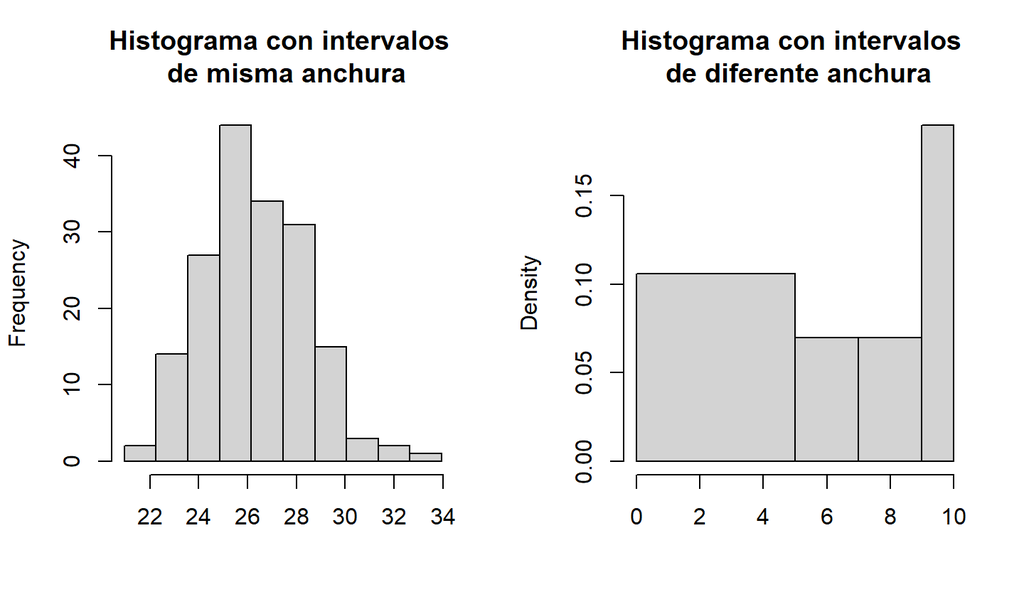

## Interpretación de los histogramas

- Histograma de frecuencias relativas: la altura, , de cada barra es la necesaria para que el área sea igual a la frecuencia relativa de la clase. La suma de todas las áreas debe ser 1. De nuevo, conviene indicar de alguna forma la frecuencia que representa cada barra.
- Histogramas de frecuencias acumuladas: las alturas de las barras son iguales a las frecuencias acumuladas de las clases, independientemente de su amplitud.

## Frecuencias nulas

No es conveniente que en un histograma aparezcan clases con frecuencia nula, exceptuando el caso en que represente poblaciones muy diferentes y separadas sin individuos intermedios.

Si apareciesen clases vacías, convendría utilizar un número menor de clases, o bien unir las clases vacías con alguna de sus adyacentes. De este último modo romperíamos nuestro modo de trabajar con clases de la misma amplitud.

## Dibujando histogramas con R

Lo hacemos con la función `hist`, la cual ya conocemos. Su sintaxis es

`hist(x, breaks=..., freq=..., right=..., ...)`

- `x`: vector de los datos
- `breaks`: vector con los extremos de los intervalos o el número \(k\) de intervalos. Incluso podemos indicar, entre comillas, el método que deseemos para calcular el número de clases: `"Scott"`, `"Sturges"`… Eso sí, para cualquiera de las dos últimas opciones, no siempre obtendréis el número deseado de intervalos, puesto que R lo considerará solo como sugerencia. Además, recordad que el método para calcular los intervalos es diferente al de la función `cut`. Por tanto, se recomienda hacer uso de la primera opción.
- `freq=TRUE`, que es su valor por defecto, produce el histograma de frecuencias absolutas si los intervalos son todos de la misma amplitud y de frecuencias relativas en caso contrario. `freq=FALSE` nos produce siempre el de frecuencias relativas.

## Dibujando histogramas con R

- `right` funciona exactamente igual que en la función `cut`.
- `include.lowest = TRUE` también funciona exactamente igual que en la función `cut`.
- También podéis utilizar los parámetros de la función `plot` que tengan sentido

`hist` titula por defecto los histogramas del siguiente modo: “Histogram of” seguido del nombre del vector de datos. No suele quedar muy bien si no estamos haciendo nuestro análisis en inglés.

## Dibujando histogramas con R

Recordemos que el parámetro `plot` igualado a `FALSE` no dibujaba, pero sí calculaba el histograma.

La función `hist` contiene mucha información en su estructura interna

- `breaks` contiene el vector de extremos de los intervalos: \(L_1,\dots,L_{k+1}\)
- `mids` contiene los puntos medios de los intervalos, lo que nosotros consideramos las marcas de clase: \(X_1,\dots,X_k\)
- `counts` contiene el vector de frecuencias absolutas de los intervalos: \(n_1,\dots,n_k\)
- `density` contiene el vector de las densidades de los intervalos. Estas se corresponden con las alturas de las barras del histograma de frecuencias relativas. Recordemos, la densidad de un intervalo es su frecuencia relativa divida por su amplitud.

## Dibujando histogramas con R

Aquí os dejamos una función útil para calcular histogramas de frecuencias absolutas más completos:

```r
histAbs = function(x,L) {
  h = hist(x, breaks = L, right = FALSE, freq = FALSE,
           xaxt = "n", yaxt = "n", col = "lightgray",
           main = "Histograma de frecuencias absolutas",
           xlab = "Intervalos y marcas de clase",
           ylab = "Frecuencias absolutas")
  axis(1, at=L)
  text(h$mids, h$density/2, labels=h$counts, col="purple")
  }
```

- `xaxt="n"` e `yaxt="n"` especifican que, por ahora, la función no dibuje los ejes de abcisas y ordenadas, respectivamente.

## Dibujando histogramas con R

- `axis(i, at=...)` dibuja el eje correspondiente al valor de \(i\) con marcas en los lugares indicados por el vector definido mediante `at`. Si \(i=1\), el de abcisas; si \(i=2\), el de ordenadas.

Os habréis fijado que con `freq = FALSE` en realidad hemos dibujado un histograma de frecuencias relativas, pero al haber omitido el eje de ordenadas, da lo mismo. En cambio, sí que nos ha sido útil para poder añadir, con la función `text`, la frecuencia absoluta de cada clase sobre el punto medio de su intervalo, los valores `h$mids` y a media algura de su barra, correspondiente a `h$density` gracias a que, con `freq = FALSE` estas alturas se corresponden con la densidad.

## Dibujando histogramas con R

Otra forma de indicar las frecuencias absolutas de las barras es utilizar la función `rug`, la cual permite añadir al histograma una “alfombra” con marcas en todos los valores del vector, donde el grosor de cada marca es proporcional a la frecuencia del valor que representa.

Existe la posibilidad de añadir un poco de ruido a los datos de un vector para deshacer posibles empates. Esto lo conseguimos combinando la función `rug` con `jitter`.

## Dibujando histogramas con R

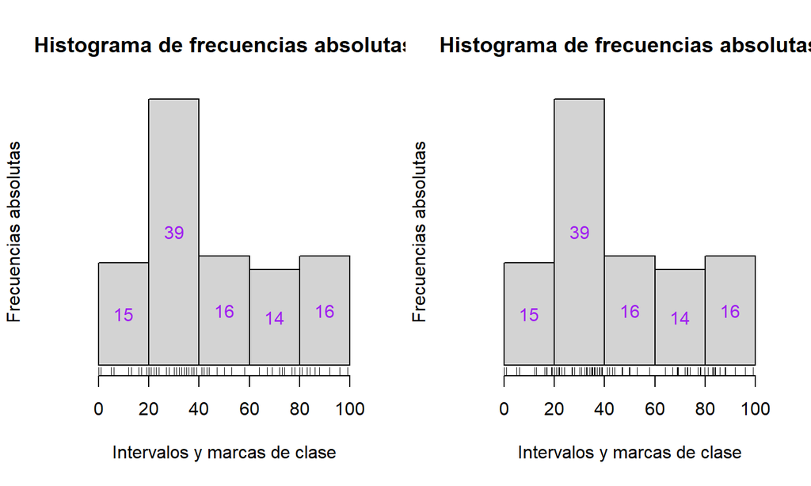

## Dibujando histogramas con R

Aquí os dejamos una función útil para calcular histogramas de frecuencias absolutas acumuladas más completos:

```r
histAbsCum = function(x,L) {
  h = hist(x, breaks = L, right = FALSE , plot = FALSE)
  h$density = cumsum(h$density)
  plot(h, freq = FALSE, xaxt = "n", yaxt = "n", col = "lightgray",
       main = "Histograma de frecuencias\nabsolutas acumuladas",
       xlab = "Intervalos", ylab = "Frec. absolutas acumuladas")
  axis(1, at=L)
  text(h$mids, h$density/2, labels = cumsum(h$counts), col = "purple")
  }
```

## Dibujando histogramas con R

Con la función anterior, lo que hacemos es, en primer lugar, producir el histograma básico de los datos, sin dibujarlo para a continuación modificar la componente `density` para que contenga las sumas acumuladas de esta componente del histograma original.

Seguidamente, dibujamos el nuevo histograma resultante, aplicando la función `plot`. Es aquí donde debemos especificar los parámetros y no en el histograma original.

Finalmente, añadimos el eje de abcisas y las frecuencias acumuladas en color lila.

## Dibujando histogramas con R

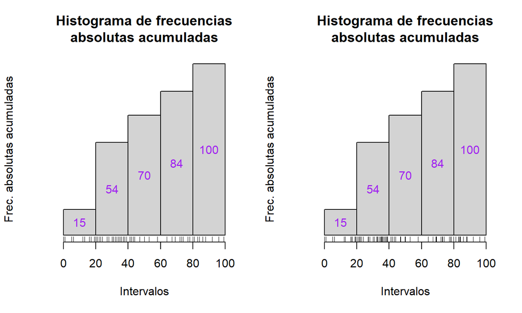

## Histogramas de frecuencias relativas

En estos histogramas, es común superponer una curva que estime la densidad de la distribución de la variable cuantitativa definida por la característica que estamos midiendo.

La de una variable es una curva cuya área comprendida entre el eje de las abcisas y la propia curva sobre un intervalo es igual a la fracción de individuos de la población que caen dentro de ese intervalo.

Para hacernos una idea visual, imaginad que vais aumentando el tamaño de la muestra a la vez que agrupáis los datos en un conjunto cada vez mayor de clases. Si el rango de los datos se mantiene constante, la amplitud de las clases del histograma irá menguando. Además, cuando \(n\), el tamaño de la muestra, tiende a infinito, los intervalos tienden a ser puntos y, a su vez, las barras tienden a ser líneas verticales. Pues bien, los extremos superiores de estas líneas serán los que dibujen la densidad de la variable.

## Campana de Gauss

Es la densidad más famosa: la [Campana de Gauss](https://es.wikipedia.org/wiki/Función_gaussiana) Ésta se corresponde con una variable que siga una distribución nomal.

La forma de la campana depende de dos parámetros: el valor medio, \(\mu\), y su desviación típica, \(\sigma\).

## Campana de Gauss

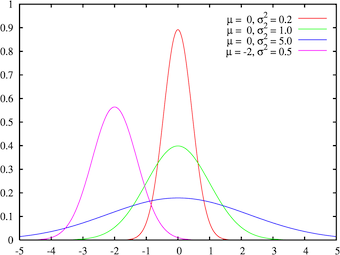

## Dibujando la curva de densidad

Existen muchos métodos con los cuales estimar la densidad de distribución a partir de una muestra.

Una de ellas es mediante la función `density` de R. Al aplicarla a un conjunto de datos, produce una `list` que incluye los vectores `x` e `y` que continen la primera y segunda coordenadas, respectivamente, de 512 puntos de la forma \((x,y)\) sobre la curva de densidad estimada.

Aplicando `plot` o `lines` a este resultado según pertoque, obtenemos la representación gráfica de esta curva.

## Histogramas de frecuencias relativas

Aquí os dejamos una función útil para calcular histogramas de frecuencias relativas más completos:

```r
histRel = function(x,L) {
  h = hist(x, breaks=L, right=FALSE , plot=FALSE)
  t = round(1.1*max(max(density(x)[[2]]),h$density),2)
  plot(h, freq = FALSE, col = "lightgray",
       main = "Histograma de frec. relativas\ny curva de densidad estimada",
       xaxt="n", ylim=c(0,t), xlab="Intervalos", ylab="Densidades")
  axis(1, at = L)
  text(h$mids, h$density/2, labels = round(h$counts/length(x),2),
       col = "blue")
  lines(density(x), col = "purple", lwd = 2)
  }
```

## Histogramas de frecuencias relativas

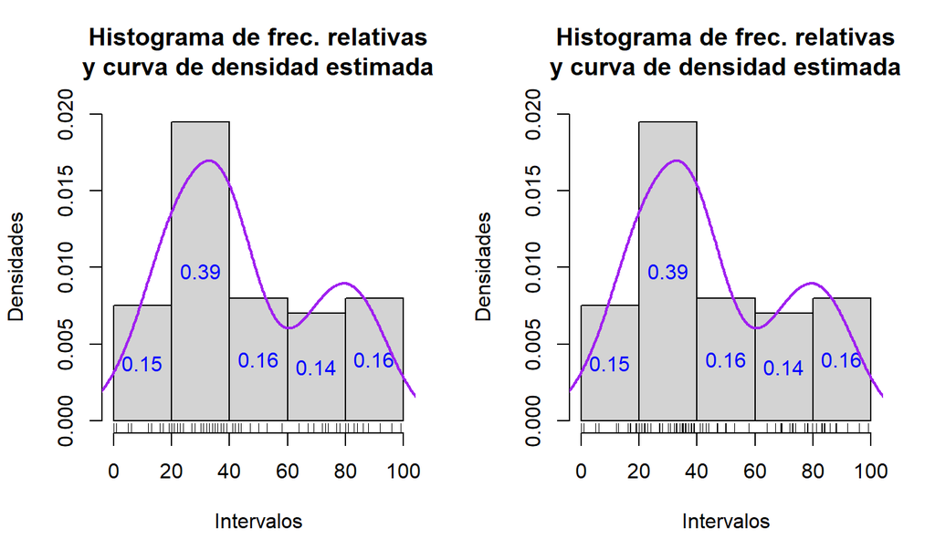

## Histogramas de frecuencias relativas acumuladas

En este último tipo de histograma, se suele superponer una curva que estime la de la variable definida por la característica que estamos midiendo.

Esta función de distribución, en cada punto nos da la fracción de individuos de la población que caen a la izquierda de este punto: su frecuencia relativa acumulada.

En general, la función de distribución en un valor determinado se obtiene hallando el área de la función de densidad que hay a la izquierda del valor.

## Histogramas de frecuencias relativas acumuladas

Aquí os dejamos una función útil para calcular histogramas de frecuencias relativas acumuladas más completos:

```r
histRelCum = function(x,L){
  h = hist(x, breaks = L, right = FALSE , plot = FALSE)
  h$density = cumsum(h$counts)/length(x)
  plot(h, freq = FALSE,
      main = "Histograma de frec. rel. acumuladas\n y
      curva de distribución estimada",
      xaxt = "n", col = "lightgray", xlab = "Intervalos",
      ylab = "Frec. relativas acumuladas")
  axis(1, at = L)
  text(h$mids, h$density/2, labels = round(h$density ,2), col = "blue")
  dens.x = density(x)
  dens.x$y = cumsum(dens.x$y)*(dens.x$x[2]-dens.x$x[1])
  lines(dens.x,col = "purple",lwd = 2)
}
```

## Histogramas de frecuencias relativas acumuladas

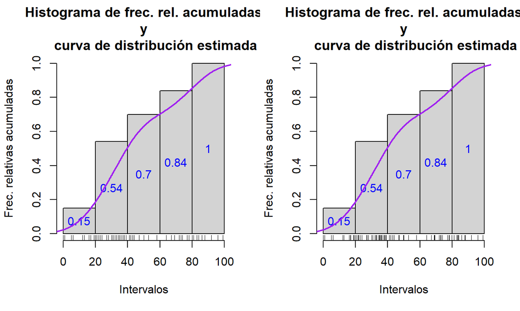

## Enunciado

**Ejemplo 2 - Continuación**

Vamos a seguir trabajando con nuestra variable `cw` y, esta vez, lo que haremos será calcular histogramas de todas las formas explicadas anteriormente.

## Solución

Dibujamos el histograma con `hist` y luego observamos su información interna.

```r
hist(cw, breaks = L, right = FALSE, main = "Histograma de las
     anchuras de los cangrejos")
```

## Solución

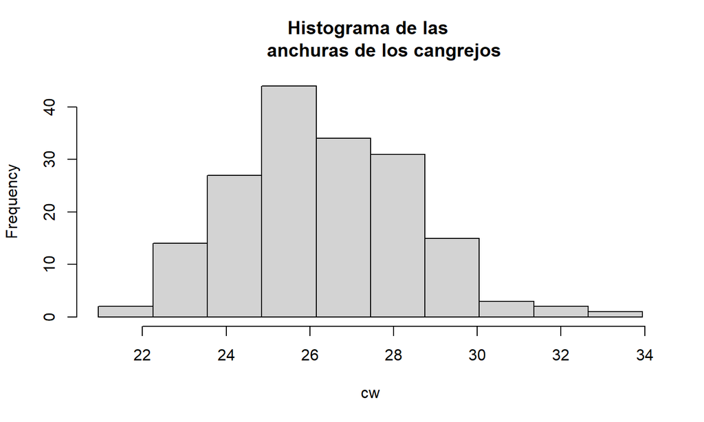

## Solución

```r
hist(cw, breaks = L, right = FALSE, plot = FALSE)
```

```
$breaks
 [1] 20.95 22.25 23.55 24.85 26.15 27.45 28.75 30.05 31.35 32.65 33.95

$counts
 [1]  2 14 27 44 34 31 15  3  2  1

$density
 [1] 0.008892841 0.062249889 0.120053357 0.195642508 0.151178301 0.137839040
 [7] 0.066696309 0.013339262 0.008892841 0.004446421

$mids
 [1] 21.6 22.9 24.2 25.5 26.8 28.1 29.4 30.7 32.0 33.3

$xname
[1] "cw"

$equidist
[1] TRUE

attr(,"class")
[1] "histogram"
```

## Solución

Dibujamos el histograma con `histAbs`.

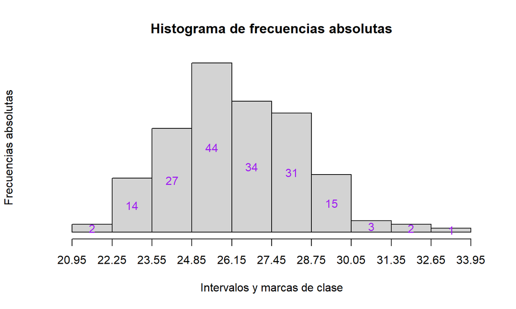

```r
histAbs(cw,L)
```

## Solución

Dibujamos el histograma con `histAbsCum`.

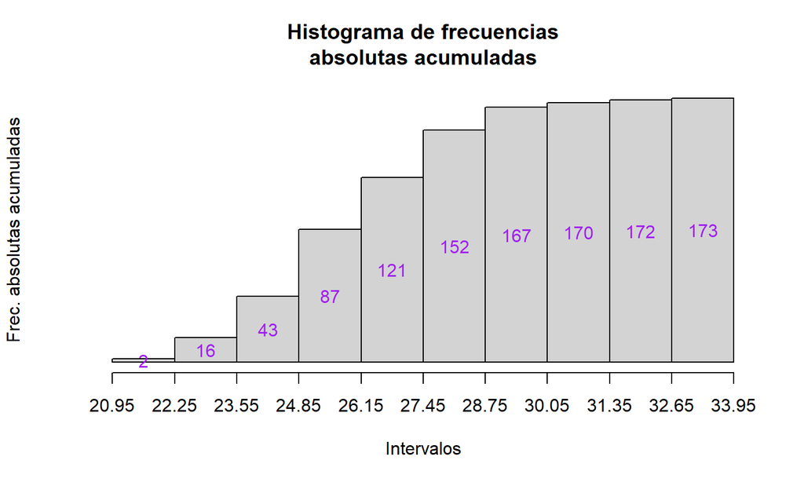

```r
histAbsCum(cw,L)
```

## Solución

Hacemos uso de las funciones `rug` y `jitter`

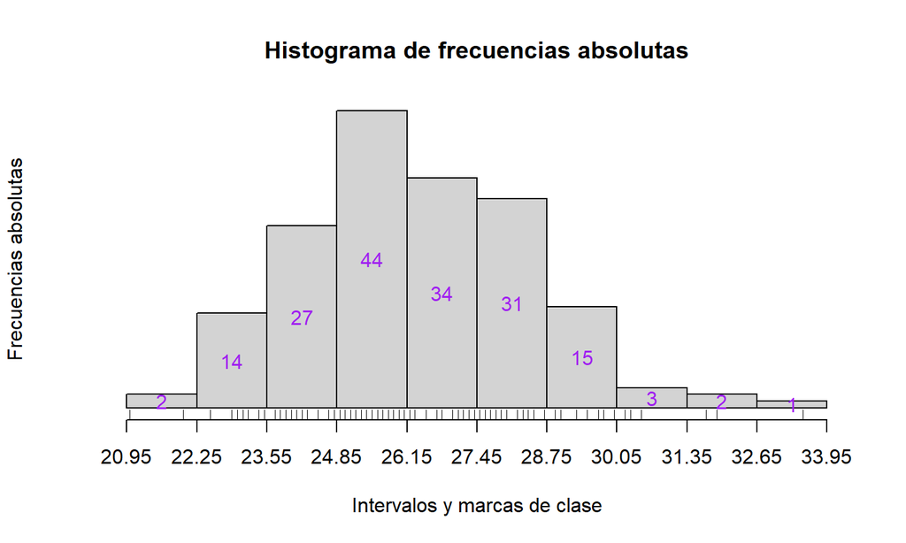

```r
histAbs(cw,L)
rug(cw)
```

## Solución

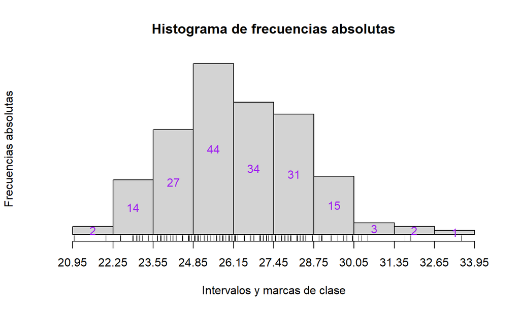

```r
histAbs(cw,L)
rug(jitter(cw))
```

## Solución

A continuación, calculamos la densidad de `cw` y la representamos con `histRel`

```r
str(density(cw))
```

```
List of 8
 $ x         : num [1:512] 19 19 19.1 19.1 19.1 ...
 $ y         : num [1:512] 3.86e-05 4.46e-05 5.13e-05 5.89e-05 6.76e-05 ...
 $ bw        : num 0.671
 $ n         : int 173
 $ old.coords: logi FALSE
 $ call      : language density.default(x = cw)
 $ data.name : chr "cw"
 $ has.na    : logi FALSE
 - attr(*, "class")= chr "density"
```

## Solución

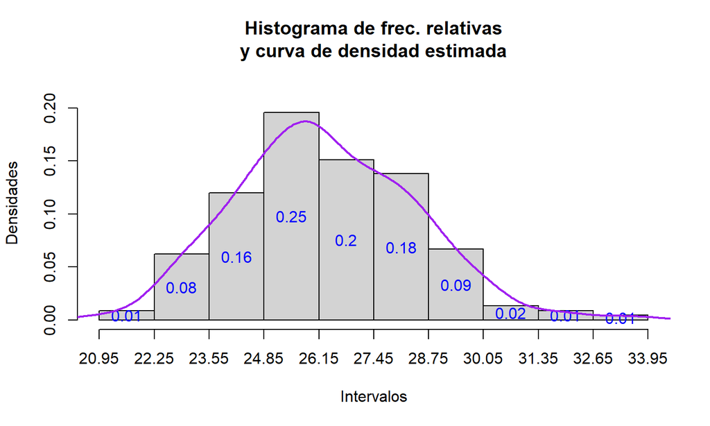

```r
histRel(cw,L)
```

## Solución

La curva de densidad que hemos obtenemos en este gráfico tiene una forma de campana que nos recuerda la campana de Gauss. Para explorar este parecido, vamos a añadir al histograma la gráfica de la función densidad de una distribución normal de media y desviación típica las del conjunto de datos original

Así, aplicando las instrucciones siguientes, acabamos obteniendo

```r
histRel(cw,L)
curve(dnorm(x, mean(cw), sd(cw)), col="cyan4", lty=4, lwd=2,
add=TRUE)
legend("topright", lwd=c(2,2), lty=c(1,4), col=c("purple","cyan4"),
       legend=c("densidad estimada","densidad normal"))
```

## Solución

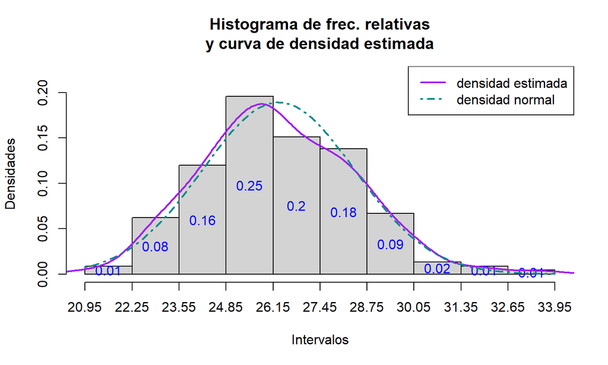

## Solución

Dibujamos el histograma con `histRelCum`.

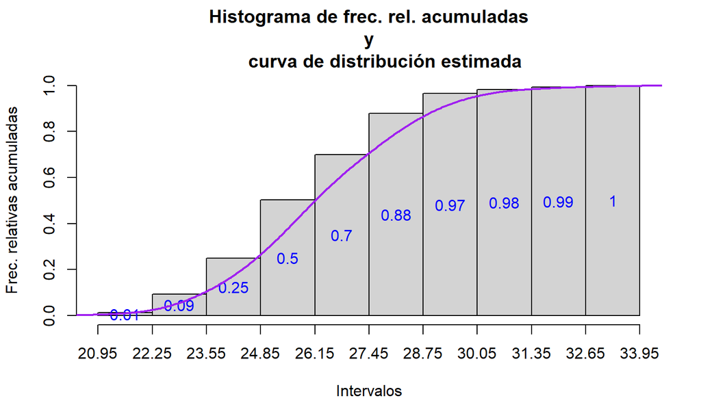

```r
histRelCum(cw,L)
```